# 03_sda_telecom_research_accepted

Hello, Jolene! My name is Olga. I'm happy to reviewing your project today.

You can find my comments in green, yellow or red boxes like this:

**Reviewer's comment** Success. Everything is done succesfully.

**Reviewer's comment** Remarks. Some recommendations.

**Reviewer's comment** Needs fixing. The block requires some corrections. Work can't be accepted with the red comments.

**Please don't remove my comments :)**

You can answer me by using this:

**Student answer.**

Hi Olga, thank you for your feedback and comments! I want to be a good coder, so I appreciate feedback.

I think what you are asking is interesting and I tried to answer them, however my understanding is that it is out of the scope of the directions because the questions ask for the monthly totals.

I have updated some of the things you asked:

- I created a table of the total calls, mins, texts, gbs per client and plotted some graphs
  - I hope this is what you were looking for
- for the hypothesis testing I am not sure how to proceed with the totals you requested and have an appropriate population per plan

**Student answer. V.2.**

- Hi Olga, I did my best to work on your requests, but I am very lost on the assignment. I am going to reach out to the community manager to see if i can get clarification
- At this time, I dont think it is correct to calculate the charges based on the yearly total minutes, texts, and gbs, because the over use needs to be calculated for each month
- These are the updates I made for V.2.
  - updated the usage totals for each type (calls, mins, texts, gbs)
  - graphed distributions on the same graph
  - updated my hypotheses and conclusions because I realized I set the null incorrectly

**Overallv reviewer's comment.V.3.** Hello Jolene! Your third version is brilliant! Now we have right graphs and hypotheses. Well done! I asked your tutor to help you with your questions and write an example in the end of project.Please, look at my code. It is a possible way for calculate and merge our datasets.I hope it will help and your next project will be easly. You done a really good job here. I think clients will be happy to see such detailed project. Keep up the good work, and good luck on the next sprint! :)

**Overallv reviewer's comment.V.2.** Hello Jolene! I really appreciate the corrections you sent in! Thanks for taking the time to do so. I hope my comments help you and you improve you skills. I'm really glad to see that the part regarding total values is much improved! However, one other part needs a bit more work. Here is a point to help you put the final touches on your project: you need to add some columns in your new total table and check hypothesis with this new dataframe. Could you take a second glance at it? When you get a moment, shoot back a second round of corrections, and I'll take a look to make sure everything is perfect. One more time and you'll have it! :)

**Overallv reviewer's comment** Jolene, thank you for sending your project. You've done a really good job on it! While there's room for improvement, on the whole, your project is impressive good. You made a very detailed research and it is very good! I like your functions and project style. You did a great job! I am really impressed! There are few things that need to be corrected in your project.Please, try to make your project more general. I wrote comments, please, check them. You're almost there! Good luck! :)

# Megaline's commercial department wants to know which plan brings in more revenue, Surf or Ultimate, so they can adjust their advertising budget.

*Tasks:*

- Carry out preliminary analysis using data from 500 Megaline clients
  - Convert data to necessary types
  - Find and eliminate errors in the data
  - Provide an explanation of errors found and how they were eliminated/processed
- Evaluate:
  - Who the clients are
  - Where are the clients from
  - Which plan the clients use
  - The number of calls made in 2018
  - The number of texts sent in 2018
- Analyze clients behavior
  - For each client, find:
    - The number of calls made each month
    - The number of minutes used each month
    - The number of texts sent each month
    - The volume of data used each month
    - The monthly revenue
- Determine which prepaid plan brings in more revenue
  - Test the following hypotheses:
    - The average revenue from users of Ultimate and Surf calling plans differs
    - The average revenue from users in NYNJ area is different from that of the users from other regions.
  - Explain
    - The formulation of the null and althernative hypotheses
    - What criterion you used to test the hypotheses and why.

*Important notes:*

- Megaline rounds seconds to minutes for each call (1 second rounds to 1 minute)
- Megaline rounds mbs to gbs for the whole month, there are 1024mb in 1gb (1025mb rounds to 2gb)
- churn_date column: the date the user stopped using the service (if the value is missing, the calling plan was being used when this data was generated)
- Plan details:
  - Surf
    - Monthly charge: 20 dollars
    - 500 monthly minutes, 50 texts, and 15 GB of data
    - After exceeding the package limits:
      - 1 minute: 3 cents
      - 1 text message: 3 cents
      - 1 GB of data: 10 dollars
  - Ultimate
    - Monthly charge: 70 dollars
    - 3000 monthly minutes, 1000 text messages, and 30 GB of data
    - After exceeding the package limits:
      - 1 minute: 1 cent
      - 1 text message: 1 cent
      - 1 GB of data: 7 dollars

# Plan of action

1. Import Libraries
2. Open the data files and study the general information
3. Data Preprocessing
   - 3.a. Clean up the data
   - 3.b. Calculate requested information
4. Analyze the data
5. Answer hypotheses questions

**Reviewer's comment** Great start with detailed introduction! And I see libraries at the beginning. Very good!

# 1. Import Libraries

```python
import pandas as pd
import numpy as np
import matplotlib.pyplot as plt
import datetime
import math as mt
from scipy import stats as st
from functools import reduce
```

# 2. Open the data file and study the general information

*Read tables as dataframes and examine the original data*

```python
calls_orig = pd.read_csv('/datasets/megaline_calls.csv')
internet_orig = pd.read_csv('/datasets/megaline_internet.csv')
messages_orig = pd.read_csv('/datasets/megaline_messages.csv')
plans_orig = pd.read_csv('/datasets/megaline_plans.csv')
users_orig = pd.read_csv('/datasets/megaline_users.csv')
```

```python
print('Call dataframe')
calls_orig.head()
```

```
Call dataframe
```

|  | id | user_id | call_date | duration |
| --- | --- | --- | --- | --- |
| 0 | 1000_93 | 1000 | 2018-12-27 | 8.52 |
| 1 | 1000_145 | 1000 | 2018-12-27 | 13.66 |
| 2 | 1000_247 | 1000 | 2018-12-27 | 14.48 |
| 3 | 1000_309 | 1000 | 2018-12-28 | 5.76 |
| 4 | 1000_380 | 1000 | 2018-12-30 | 4.22 |

```python
print('call dataframe info')
calls_orig.info()
```

```
call dataframe info
<class 'pandas.core.frame.DataFrame'>
RangeIndex: 137735 entries, 0 to 137734
Data columns (total 4 columns):
id           137735 non-null object
user_id      137735 non-null int64
call_date    137735 non-null object
duration     137735 non-null float64
dtypes: float64(1), int64(1), object(2)
memory usage: 4.2+ MB
```

```python
print('Number of clients that made calls in the data provided')
calls_orig['user_id'].value_counts().count()
```

```
Number of clients that made calls in the data provided
```

```
481
```

```python
print('count of call durations')
calls_orig['duration'].value_counts(dropna=False)
```

```
count of call durations
```

```
0.00     26834
8.37       102
4.02       102
3.91       101
7.61       100
         ...
25.53        1
29.34        1
26.05        1
36.24        1
27.16        1
Name: duration, Length: 2802, dtype: int64
```

```python
print('count of call dates')
calls_orig['call_date'].value_counts(dropna=False)
```

```
count of call dates
```

```
2018-12-27    1091
2018-12-28    1085
2018-12-30    1080
2018-12-24    1078
2018-12-29    1070
              ...
2018-01-17       6
2018-01-26       6
2018-01-15       5
2018-01-18       4
2018-01-24       3
Name: call_date, Length: 351, dtype: int64
```

```python
print('internet use dataframe')
internet_orig.head()
```

```
internet use dataframe
```

|  | id | user_id | session_date | mb_used |
| --- | --- | --- | --- | --- |
| 0 | 1000_13 | 1000 | 2018-12-29 | 89.86 |
| 1 | 1000_204 | 1000 | 2018-12-31 | 0.00 |
| 2 | 1000_379 | 1000 | 2018-12-28 | 660.40 |
| 3 | 1000_413 | 1000 | 2018-12-26 | 270.99 |
| 4 | 1000_442 | 1000 | 2018-12-27 | 880.22 |

```python
print('internet use info')
internet_orig.info()
```

```
internet use info
<class 'pandas.core.frame.DataFrame'>
RangeIndex: 104825 entries, 0 to 104824
Data columns (total 4 columns):
id              104825 non-null object
user_id         104825 non-null int64
session_date    104825 non-null object
mb_used         104825 non-null float64
dtypes: float64(1), int64(1), object(2)
memory usage: 3.2+ MB
```

```python
print('Number of clients that used data in the data provided')
internet_orig['user_id'].value_counts().count()
```

```
Number of clients that used data in the data provided
```

```
489
```

```python
print('count of mbs used')
internet_orig['mb_used'].value_counts(dropna=False)
```

```
count of mbs used
```

```
0.00      13747
414.46        8
435.77        8
417.46        7
313.79        7
          ...
638.12        1
217.39        1
683.90        1
243.97        1
563.11        1
Name: mb_used, Length: 57624, dtype: int64
```

```python
print('dates internet was used')
internet_orig['session_date'].value_counts(dropna=False)
```

```
dates internet was used
```

```
2018-12-24    851
2018-12-30    845
2018-12-27    830
2018-12-21    826
2018-12-31    823
             ...
2018-01-23      3
2018-01-18      2
2018-01-20      2
2018-01-16      2
2018-01-15      2
Name: session_date, Length: 351, dtype: int64
```

```python
print('messages dataframe')
messages_orig.head()
```

```
messages dataframe
```

|  | id | user_id | message_date |
| --- | --- | --- | --- |
| 0 | 1000_125 | 1000 | 2018-12-27 |
| 1 | 1000_160 | 1000 | 2018-12-31 |
| 2 | 1000_223 | 1000 | 2018-12-31 |
| 3 | 1000_251 | 1000 | 2018-12-27 |
| 4 | 1000_255 | 1000 | 2018-12-26 |

```python
print('messages info')
messages_orig.info()
```

```
messages info
<class 'pandas.core.frame.DataFrame'>
RangeIndex: 76051 entries, 0 to 76050
Data columns (total 3 columns):
id              76051 non-null object
user_id         76051 non-null int64
message_date    76051 non-null object
dtypes: int64(1), object(2)
memory usage: 1.7+ MB
```

```python
print('Number of clients that sent texts in the data provided')
messages_orig['user_id'].value_counts().count()
```

```
Number of clients that sent texts in the data provided
```

```
402
```

```python
print('dates messages were sent')
messages_orig['message_date'].value_counts()
```

```
dates messages were sent
```

```
2018-12-28    702
2018-12-27    701
2018-12-25    699
2018-12-31    699
2018-12-18    688
             ...
2018-01-21      3
2018-02-18      2
2018-01-15      2
2018-01-24      2
2018-01-19      1
Name: message_date, Length: 351, dtype: int64
```

```python
print('plans dataframe')
plans_orig.head()
```

```
plans dataframe
```

|  | messages_included | mb_per_month_included | minutes_included | usd_monthly_pay | usd_per_gb | usd_per_message | usd_per_minute | plan_name |
| --- | --- | --- | --- | --- | --- | --- | --- | --- |
| 0 | 50 | 15360 | 500 | 20 | 10 | 0.03 | 0.03 | surf |
| 1 | 1000 | 30720 | 3000 | 70 | 7 | 0.01 | 0.01 | ultimate |

```python
print('plans info')
plans_orig.info()
```

```
plans info
<class 'pandas.core.frame.DataFrame'>
RangeIndex: 2 entries, 0 to 1
Data columns (total 8 columns):
messages_included        2 non-null int64
mb_per_month_included    2 non-null int64
minutes_included         2 non-null int64
usd_monthly_pay          2 non-null int64
usd_per_gb               2 non-null int64
usd_per_message          2 non-null float64
usd_per_minute           2 non-null float64
plan_name                2 non-null object
dtypes: float64(2), int64(5), object(1)
memory usage: 256.0+ bytes
```

```python
print('users dataframe')
users_orig.head()
```

```
users dataframe
```

|  | user_id | first_name | last_name | age | city | reg_date | plan | churn_date |
| --- | --- | --- | --- | --- | --- | --- | --- | --- |
| 0 | 1000 | Anamaria | Bauer | 45 | Atlanta-Sandy Springs-Roswell, GA MSA | 2018-12-24 | ultimate | NaN |
| 1 | 1001 | Mickey | Wilkerson | 28 | Seattle-Tacoma-Bellevue, WA MSA | 2018-08-13 | surf | NaN |
| 2 | 1002 | Carlee | Hoffman | 36 | Las Vegas-Henderson-Paradise, NV MSA | 2018-10-21 | surf | NaN |
| 3 | 1003 | Reynaldo | Jenkins | 52 | Tulsa, OK MSA | 2018-01-28 | surf | NaN |
| 4 | 1004 | Leonila | Thompson | 40 | Seattle-Tacoma-Bellevue, WA MSA | 2018-05-23 | surf | NaN |

```python
print('users info')
users_orig.info()
```

```
users info
<class 'pandas.core.frame.DataFrame'>
RangeIndex: 500 entries, 0 to 499
Data columns (total 8 columns):
user_id       500 non-null int64
first_name    500 non-null object
last_name     500 non-null object
age           500 non-null int64
city          500 non-null object
reg_date      500 non-null object
plan          500 non-null object
churn_date    34 non-null object
dtypes: int64(2), object(6)
memory usage: 31.4+ KB
```

```python
print('Number of clients in the data provided')
print(users_orig['user_id'].value_counts().count())
```

```
Number of clients in the data provided
500
```

```python
print('Number of clients using each plan')
print(users_orig['plan'].value_counts())
```

```
Number of clients using each plan
surf        339
ultimate    161
Name: plan, dtype: int64
```

```python
print('churn dates, i.e. dates clients ended service')
users_orig['churn_date'].value_counts()
```

```
churn dates, i.e. dates clients ended service
```

```
2018-12-18    3
2018-11-14    2
2018-12-31    2
2018-12-19    2
2018-10-03    1
2018-11-18    1
2018-10-07    1
2018-09-01    1
2018-07-31    1
2018-12-22    1
2018-12-30    1
2018-11-29    1
2018-11-30    1
2018-10-13    1
2018-09-07    1
2018-12-12    1
2018-12-15    1
2018-09-18    1
2018-08-19    1
2018-11-16    1
2018-12-26    1
2018-11-24    1
2018-12-10    1
2018-10-22    1
2018-08-16    1
2018-09-17    1
2018-11-11    1
2018-12-27    1
2018-11-21    1
Name: churn_date, dtype: int64
```

```python
print('cities clients are from')
users_orig['city'].value_counts()
```

```
cities clients are from
```

```
New York-Newark-Jersey City, NY-NJ-PA MSA          80
Los Angeles-Long Beach-Anaheim, CA MSA             29
Dallas-Fort Worth-Arlington, TX MSA                21
Chicago-Naperville-Elgin, IL-IN-WI MSA             19
Philadelphia-Camden-Wilmington, PA-NJ-DE-MD MSA    17
                                                   ..
Cape Coral-Fort Myers, FL MSA                       1
Oxnard-Thousand Oaks-Ventura, CA MSA                1
Raleigh-Cary, NC MSA                                1
Stockton, CA MSA                                    1
Albany-Schenectady-Troy, NY MSA                     1
Name: city, Length: 73, dtype: int64
```

# 2. Conclusion of original data

*Actions Performed*

- Original files were read as dataframes and the following were examined:
  - The first 5 rows of each file/dataframe
  - The general information of each dataframe
  - Counts of the user_id columns where appropriate to examine the number of unique clients being accounted for in each dataframe

*General information*

*File based information*

Calls file:

- 137735 entries
- 481 unique users made phone calls
- 26834 calls lasted for 0 minutes
- contains:
  - id: unique call identifier
    - change to represent the file it comes from
  - user_id: unique user identifier
  - call_date: date of the call
    - data type = object - this needs to be changed to datetime
  - duration: duration of the call (in minutes)
    - measurement should be added to the column name

Internet file:

- 104825 entries
- 489 unique users used the internet
- 13747 sessions used 0 mbs
- contains:
  - id: unique session identifier
    - change to represent the file it comes from
  - user_id: unique user indentifer
  - session_date: date of session
    - data type = object - this needs to be changed to datetime
  - mb_used: the volume of data spent during the session (in megabytes)
    - measurement should be added to the column name

Messages file:

- 76051 entries
- 402 unique users sent messages
- contains:
  - id: unique text message identifier
    - change to represent the file it comes from
  - user_id: unique user indentifer
  - message_date: date message was sent
    - data type = object - this needs to be changed to datetime

Plans file:

- 2 entries
- contains:
  - information about each plan
  - plan_name: calling plan name
  - usd_monthly_fee: monthly charge in US dollars
  - minutes_included: monthly minute allowance
  - messages_included: monthly text allowance
  - mb_per_month_included: data volume allowance (in megabytes)
  - usd_per_minute: price per minute after exceeding the package limits
  - usd_per_message: price per text after exceeding the package limits
  - usd_per_gb: price per extra gigabyte of data after exceeding the package limits

Users file:

- 500 entries
- contains:
  - information about each client in the data sample
  - user_id: unique user identifier
  - first_name: user's name
  - last_name: user's last name
  - age: user's age (years)
  - reg_date: subscription date (dd, mm, yy)
    - data type = object - this needs to be changed to datetime
  - churn_date: the date the user stopped using the service (if the value is missing, the calling plan was being used when this data was generated)
    - data type = object - this needs to be changed to datetime
  - city: user's city of residence
  - plan: calling plan name
- One column contains missing values

**Reviewer's comment** So, we have basic information about our data and ready to change something. :)

# 3.a. Data Preprocessing

*Action Plan*

- Read and save a working version of the data files
- Update column names where appropriate:
  - Rename 'id' columns in megaline_calls.csv, megaline_internet.csv, and megaline_messages.csv files to represent the files they come from
  - Include units of measurements
- Identify missing values in each file
  - Determine impact of missing values
  - Process missing values appropriately
- Identify any duplicate values in each file
  - Remove or process duplicate values
- Identify data types that are inappropriate and change them to an appropriate or more useful data type for each file
- Examine calls lasting for 0 minutes
  - Process or remove the data where appropriate
- Examine internet sessions that used 0 mbs
  - Process or remove the data where appropriate

*Read and save a working version of data files*

```python
# create working versions of dataframes
calls = pd.read_csv('/datasets/megaline_calls.csv')
internet = pd.read_csv('/datasets/megaline_internet.csv')
messages = pd.read_csv('/datasets/megaline_messages.csv')
plans = pd.read_csv('/datasets/megaline_plans.csv')
users = pd.read_csv('/datasets/megaline_users.csv')
```

*Rename columns to better represent the information*

- Change 'id' columns to represent the file it is from
- Add units of measurement

```python
# rename columns
calls.rename(columns={'id' : 'call_id', 'duration' : 'duration_min'}, inplace=True)
internet.rename(columns={'id' : 'session_id'}, inplace=True)
messages.rename(columns={'id' : 'message_id'}, inplace=True)
```

```python
# confirm column names are changed
print('call dataframe columns updated')
calls.columns
```

```
call dataframe columns updated
```

```
Index(['call_id', 'user_id', 'call_date', 'duration_min'], dtype='object')
```

```python
# confirm column names are changed
print('internet dataframe columns updated')
internet.columns
```

```
internet dataframe columns updated
```

```
Index(['session_id', 'user_id', 'session_date', 'mb_used'], dtype='object')
```

```python
# confirm column names are changed
print('messages dataframe columns updated')
messages.columns
```

```
messages dataframe columns updated
```

```
Index(['message_id', 'user_id', 'message_date'], dtype='object')
```

*Identify missing values in each file and determine it's impact & Process missing values where appropriate*

```python
print('number of missing values in call dataframe')
calls.isnull().sum()
```

```
number of missing values in call dataframe
```

```
call_id         0
user_id         0
call_date       0
duration_min    0
dtype: int64
```

```python
print('number of missing values in internet dataframe')
internet.isnull().sum()
```

```
number of missing values in internet dataframe
```

```
session_id      0
user_id         0
session_date    0
mb_used         0
dtype: int64
```

```python
print('number of missing values in messages dataframe')
messages.isnull().sum()
```

```
number of missing values in messages dataframe
```

```
message_id      0
user_id         0
message_date    0
dtype: int64
```

```python
print('number of missing values in plans dataframe')
plans.isnull().sum()
```

```
number of missing values in plans dataframe
```

```
messages_included        0
mb_per_month_included    0
minutes_included         0
usd_monthly_pay          0
usd_per_gb               0
usd_per_message          0
usd_per_minute           0
plan_name                0
dtype: int64
```

```python
print('number of missing values in users dataframe')
users.isnull().sum()
```

```
number of missing values in users dataframe
```

```
user_id         0
first_name      0
last_name       0
age             0
city            0
reg_date        0
plan            0
churn_date    466
dtype: int64
```

```python
print('Percentage of missing values in users dataframe')
users.isnull().sum() / len(users_orig) * 100
```

```
Percentage of missing values in users dataframe
```

```
user_id        0.0
first_name     0.0
last_name      0.0
age            0.0
city           0.0
reg_date       0.0
plan           0.0
churn_date    93.2
dtype: float64
```

```python
print('users dataframe info')
users.info()
```

```
users dataframe info
<class 'pandas.core.frame.DataFrame'>
RangeIndex: 500 entries, 0 to 499
Data columns (total 8 columns):
user_id       500 non-null int64
first_name    500 non-null object
last_name     500 non-null object
age           500 non-null int64
city          500 non-null object
reg_date      500 non-null object
plan          500 non-null object
churn_date    34 non-null object
dtypes: int64(2), object(6)
memory usage: 31.4+ KB
```

*Change the current clients 'missing' churn date from NaN to None*

```python
# change missing values from NaN to None
users.loc[users['churn_date'].isnull(), 'churn_date'] = None
print('users dataframe with updated missing values changed from NaN to None')
users.head()
```

```
users dataframe with updated missing values changed from NaN to None
```

|  | user_id | first_name | last_name | age | city | reg_date | plan | churn_date |
| --- | --- | --- | --- | --- | --- | --- | --- | --- |
| 0 | 1000 | Anamaria | Bauer | 45 | Atlanta-Sandy Springs-Roswell, GA MSA | 2018-12-24 | ultimate | None |
| 1 | 1001 | Mickey | Wilkerson | 28 | Seattle-Tacoma-Bellevue, WA MSA | 2018-08-13 | surf | None |
| 2 | 1002 | Carlee | Hoffman | 36 | Las Vegas-Henderson-Paradise, NV MSA | 2018-10-21 | surf | None |
| 3 | 1003 | Reynaldo | Jenkins | 52 | Tulsa, OK MSA | 2018-01-28 | surf | None |
| 4 | 1004 | Leonila | Thompson | 40 | Seattle-Tacoma-Bellevue, WA MSA | 2018-05-23 | surf | None |

*Identify and process any duplicate values in each file*

```python
print('number of duplicate rows in call dataframe')
calls.duplicated().sum()
```

```
number of duplicate rows in call dataframe
```

```
0
```

```python
print('number of duplicate rows in internet dataframe')
internet.duplicated().sum()
```

```
number of duplicate rows in internet dataframe
```

```
0
```

```python
print('number of duplicate rows in messages dataframe')
messages.duplicated().sum()
```

```
number of duplicate rows in messages dataframe
```

```
0
```

```python
print('number of duplicate rows in plans dataframe')
plans.duplicated().sum()
```

```
number of duplicate rows in plans dataframe
```

```
0
```

```python
print('number of duplicate rows in users dataframe')
users.duplicated().sum()
```

```
number of duplicate rows in users dataframe
```

```
0
```

*Change data types to appropriate / more useful data types*

```python
# change datatypes to more appropriate types
calls['call_date'] = pd.to_datetime(calls['call_date'])
internet['session_date'] = pd.to_datetime(internet['session_date'])
messages['message_date'] = pd.to_datetime(messages['message_date'])
users['reg_date'] = pd.to_datetime(users['reg_date'])
users['churn_date'] = pd.to_datetime(users['churn_date'])
```

*Confirm data type changes*

```python
print("updated call dataframe data types")
calls.info()
```

```
updated call dataframe data types
<class 'pandas.core.frame.DataFrame'>
RangeIndex: 137735 entries, 0 to 137734
Data columns (total 4 columns):
call_id         137735 non-null object
user_id         137735 non-null int64
call_date       137735 non-null datetime64[ns]
duration_min    137735 non-null float64
dtypes: datetime64[ns](1), float64(1), int64(1), object(1)
memory usage: 4.2+ MB
```

```python
print("updated internet dataframe data types")
internet.info()
```

```
updated internet dataframe data types
<class 'pandas.core.frame.DataFrame'>
RangeIndex: 104825 entries, 0 to 104824
Data columns (total 4 columns):
session_id      104825 non-null object
user_id         104825 non-null int64
session_date    104825 non-null datetime64[ns]
mb_used         104825 non-null float64
dtypes: datetime64[ns](1), float64(1), int64(1), object(1)
memory usage: 3.2+ MB
```

```python
print("updated messages dataframe data types")
messages.info()
```

```
updated messages dataframe data types
<class 'pandas.core.frame.DataFrame'>
RangeIndex: 76051 entries, 0 to 76050
Data columns (total 3 columns):
message_id      76051 non-null object
user_id         76051 non-null int64
message_date    76051 non-null datetime64[ns]
dtypes: datetime64[ns](1), int64(1), object(1)
memory usage: 1.7+ MB
```

```python
print("updated users dataframe data types")
users.info()
```

```
updated users dataframe data types
<class 'pandas.core.frame.DataFrame'>
RangeIndex: 500 entries, 0 to 499
Data columns (total 8 columns):
user_id       500 non-null int64
first_name    500 non-null object
last_name     500 non-null object
age           500 non-null int64
city          500 non-null object
reg_date      500 non-null datetime64[ns]
plan          500 non-null object
churn_date    34 non-null datetime64[ns]
dtypes: datetime64[ns](2), int64(2), object(4)
memory usage: 31.4+ KB
```

**Reviewer's comment** Wow! You made a great job. Very good that you rename columns. Checking nulls is very important, well done!

```python
### Troubleshooting - Reviewer please ignore ####
###   it seems that as once churn_date becomes a datetime type it will not change to anything except NaT when None is used,
###   it will change to 0 though
# users.loc[users['churn_date'].isnull(), 'churn_date'] = None
# users.loc[users['churn_date'].isnull(), 'churn_date'] = 0
# users.head()
```

*Examine calls lasting for 0 minutes*

```python
# query calls lasting 0 minutes
zero_min_calls = calls.query('duration_min == "0.00"')
print('Call information with zero minute calls')
zero_min_calls.head()
```

```
Call information with zero minute calls
```

|  | call_id | user_id | call_date | duration_min |
| --- | --- | --- | --- | --- |
| 19 | 1001_4 | 1001 | 2018-12-05 | 0.0 |
| 25 | 1001_13 | 1001 | 2018-12-24 | 0.0 |
| 31 | 1001_30 | 1001 | 2018-10-17 | 0.0 |
| 32 | 1001_31 | 1001 | 2018-11-03 | 0.0 |
| 34 | 1001_35 | 1001 | 2018-12-21 | 0.0 |

```python
# determine number of unique users with 0 min calls
print('Number of users with zero minute calls')
print(zero_min_calls['user_id'].value_counts().count())
```

```
Number of users with zero minute calls
478
```

```python
# determine percentage of clients with 0 min calls
print('Percentage of users with zero minute calls')
print(100 - zero_min_calls['user_id'].value_counts().count() / len(calls) * 100)

### use the code above, like above better ###
# zero_mins = calls[calls['duration'] == 0.00].count() / len(calls) * 100
# print(zero_mins)
```

```
Percentage of users with zero minute calls
99.65295676480197
```

```python
# determine % of 0 min calls in the data
# print(zero_min_calls['user_id'].count())
print('Percentage of zero  minute calls in the data provided')
print(zero_min_calls['user_id'].count() / len(calls) * 100)
```

```
Percentage of zero  minute calls in the data provided
19.482339274694162
```

*Examine internet sessions that used 0 mbs*

```python
# query sessions using 0 mbs
zero_mb = internet.query('mb_used == 0.00')
print('Data information of zero mb sessions')
zero_mb.head()
```

```
Data information of zero mb sessions
```

|  | session_id | user_id | session_date | mb_used |
| --- | --- | --- | --- | --- |
| 1 | 1000_204 | 1000 | 2018-12-31 | 0.0 |
| 14 | 1001_26 | 1001 | 2018-09-17 | 0.0 |
| 16 | 1001_28 | 1001 | 2018-10-17 | 0.0 |
| 34 | 1001_54 | 1001 | 2018-09-02 | 0.0 |
| 43 | 1001_77 | 1001 | 2018-10-31 | 0.0 |

```python
# determine number of unique users with 0 mb sessions (out of 489)
print('Number of users with zero mb sessions')
print(zero_mb['user_id'].value_counts().count())
```

```
Number of users with zero mb sessions
477
```

```python
# determine percentage of clients with 0 mb sessions
print('Percentage of users with zero mb sessions')
print(100 - zero_mb['user_id'].value_counts().count() / len(internet) * 100)
```

```
Percentage of users with zero mb sessions
99.5449558788457
```

```python
# % of 0 mb sessions
print('Percentage of zero mb session in the data provided')
print(zero_mb['user_id'].count() / len(internet) * 100)
```

```
Percentage of zero mb session in the data provided
13.11423801574052
```

# 3.a. Conclusion of Data Preprocessing

**Reviewer's comment** Thank you for such deteiled conclusion! Your decisions about 0 minutes and 0 mbs are absolutely right! Perfect!

# 3.b. Calculate the following information

For each client, find:

- The number of calls made each month
- The number of minutes used each month
- The number of texts sent each month
- The volume of data used each month
- The monthly revenue
  - subtract the free package limit from the total number of calls, text messages, and data
  - multiply the result by the calling plan value
  - add the monthly charge depending on the calling plan

Plan of action:

- Create a new column with month number in each dataframe
- Use pivot tables to find:
  - The number of calls made each month
  - The number of minutes used each month - rounded up
  - The number of texts sent each month
  - The volume of data used each month - rounded up
- Join the tables together for easier analysis
- Calculate the monthly revenue
  - monthly minutes charge
  - monthly texts charge
  - monthly data charge
  - total monthly charge

*Find the number of calls each client made each month*

```python
print('calls dataframe')
calls.head()
```

```
calls dataframe
```

|  | call_id | user_id | call_date | duration_min |
| --- | --- | --- | --- | --- |
| 0 | 1000_93 | 1000 | 2018-12-27 | 8.52 |
| 1 | 1000_145 | 1000 | 2018-12-27 | 13.66 |
| 2 | 1000_247 | 1000 | 2018-12-27 | 14.48 |
| 3 | 1000_309 | 1000 | 2018-12-28 | 5.76 |
| 4 | 1000_380 | 1000 | 2018-12-30 | 4.22 |

```python
# create a new column that contains the month calls were made
calls['call_month'] = calls['call_date'].dt.month
print('Updated calls dataframe with month number column')
calls.head()
```

```
Updated calls dataframe with month number column
```

|  | call_id | user_id | call_date | duration_min | call_month |
| --- | --- | --- | --- | --- | --- |
| 0 | 1000_93 | 1000 | 2018-12-27 | 8.52 | 12 |
| 1 | 1000_145 | 1000 | 2018-12-27 | 13.66 | 12 |
| 2 | 1000_247 | 1000 | 2018-12-27 | 14.48 | 12 |
| 3 | 1000_309 | 1000 | 2018-12-28 | 5.76 | 12 |
| 4 | 1000_380 | 1000 | 2018-12-30 | 4.22 | 12 |

```python
# create a table with the number of calls made per month by each user
calls_per_month = calls.pivot_table(index='user_id', columns='call_month', values='duration_min', aggfunc='count')
calls_per_month.fillna(0, inplace=True)
print('Number of calls made per month for each client')
calls_per_month.head()
```

```
Number of calls made per month for each client
```

| call_month user_id | 1 | 2 | 3 | 4 | 5 | 6 | 7 | 8 | 9 | 10 | 11 | 12 |
| --- | --- | --- | --- | --- | --- | --- | --- | --- | --- | --- | --- | --- |
| 1000 | 0.0 | 0.0 | 0.0 | 0.0 | 0.0 | 0.0 | 0.0 | 0.0 | 0.0 | 0.0 | 0.0 | 16.0 |
| 1001 | 0.0 | 0.0 | 0.0 | 0.0 | 0.0 | 0.0 | 0.0 | 27.0 | 49.0 | 65.0 | 64.0 | 56.0 |
| 1002 | 0.0 | 0.0 | 0.0 | 0.0 | 0.0 | 0.0 | 0.0 | 0.0 | 0.0 | 11.0 | 55.0 | 47.0 |
| 1003 | 0.0 | 0.0 | 0.0 | 0.0 | 0.0 | 0.0 | 0.0 | 0.0 | 0.0 | 0.0 | 0.0 | 149.0 |
| 1004 | 0.0 | 0.0 | 0.0 | 0.0 | 21.0 | 44.0 | 49.0 | 49.0 | 42.0 | 61.0 | 54.0 | 50.0 |

**Reviewer's comment** Good idea!

```python
# create a table with the number of calls made per month by each user
calls_per_month_with_totals = calls.pivot_table(index='user_id', columns='call_month', values='duration_min', aggfunc='count', margins=True, margins_name='total_calls')
calls_per_month_with_totals.fillna(0, inplace=True)
print('Number of calls made per month for each client with totals')
calls_per_month_with_totals.head()
```

```
Number of calls made per month for each client with totals
```

| call_month user_id | 1 | 2 | 3 | 4 | 5 | 6 | 7 | 8 | 9 | 10 | 11 | 12 | total_calls |
| --- | --- | --- | --- | --- | --- | --- | --- | --- | --- | --- | --- | --- | --- |
| 1000 | 0.0 | 0.0 | 0.0 | 0.0 | 0.0 | 0.0 | 0.0 | 0.0 | 0.0 | 0.0 | 0.0 | 16.0 | 16 |
| 1001 | 0.0 | 0.0 | 0.0 | 0.0 | 0.0 | 0.0 | 0.0 | 27.0 | 49.0 | 65.0 | 64.0 | 56.0 | 261 |
| 1002 | 0.0 | 0.0 | 0.0 | 0.0 | 0.0 | 0.0 | 0.0 | 0.0 | 0.0 | 11.0 | 55.0 | 47.0 | 113 |
| 1003 | 0.0 | 0.0 | 0.0 | 0.0 | 0.0 | 0.0 | 0.0 | 0.0 | 0.0 | 0.0 | 0.0 | 149.0 | 149 |
| 1004 | 0.0 | 0.0 | 0.0 | 0.0 | 21.0 | 44.0 | 49.0 | 49.0 | 42.0 | 61.0 | 54.0 | 50.0 | 370 |

*Find the number of minutes each client used each month*

```python
# create a table with the number of minutes used per month by each user
min_per_month = calls.pivot_table(index='user_id', columns='call_month', values='duration_min', aggfunc='sum')
min_per_month.fillna(0, inplace=True)
min_per_month = min_per_month.add_prefix('mins_') # not sure why I can't rename, but I can add prefix... maybe bc the call_month is key to the list of values

# round the minutes up
min_per_month_round = min_per_month.applymap(np.ceil)
print('Number of minutes used (rounded up) per month for each client')
min_per_month_round.head()
```

```
Number of minutes used (rounded up) per month for each client
```

| call_month user_id | mins_1 | mins_2 | mins_3 | mins_4 | mins_5 | mins_6 | mins_7 | mins_8 | mins_9 | mins_10 | mins_11 | mins_12 |
| --- | --- | --- | --- | --- | --- | --- | --- | --- | --- | --- | --- | --- |
| 1000 | 0.0 | 0.0 | 0.0 | 0.0 | 0.0 | 0.0 | 0.0 | 0.0 | 0.0 | 0.0 | 0.0 | 117.0 |
| 1001 | 0.0 | 0.0 | 0.0 | 0.0 | 0.0 | 0.0 | 0.0 | 172.0 | 298.0 | 375.0 | 405.0 | 393.0 |
| 1002 | 0.0 | 0.0 | 0.0 | 0.0 | 0.0 | 0.0 | 0.0 | 0.0 | 0.0 | 55.0 | 360.0 | 364.0 |
| 1003 | 0.0 | 0.0 | 0.0 | 0.0 | 0.0 | 0.0 | 0.0 | 0.0 | 0.0 | 0.0 | 0.0 | 1041.0 |
| 1004 | 0.0 | 0.0 | 0.0 | 0.0 | 182.0 | 262.0 | 359.0 | 335.0 | 285.0 | 342.0 | 453.0 | 404.0 |

**Reviewer's comment** Great! We know the time. Very good. We can sum up them. :)

```python
# create a table with the number of minutes used per month by each user
min_per_month_with_totals = calls.pivot_table(index='user_id', columns='call_month', values='duration_min', aggfunc='sum', margins=True, margins_name='total')
min_per_month_with_totals.fillna(0, inplace=True)
min_per_month_with_totals = min_per_month_with_totals.add_prefix('mins_') # not sure why I can't rename, but I can add prefix... maybe bc the call_month is key to the list of values

# round the minutes up
min_per_month_round_with_totals = min_per_month_with_totals.applymap(np.ceil)
print('Number of minutes used (rounded up) per month for each client with totals')
min_per_month_round_with_totals.head()
```

```
Number of minutes used (rounded up) per month for each client with totals
```

| call_month user_id | mins_1 | mins_2 | mins_3 | mins_4 | mins_5 | mins_6 | mins_7 | mins_8 | mins_9 | mins_10 | mins_11 | mins_12 | mins_total |
| --- | --- | --- | --- | --- | --- | --- | --- | --- | --- | --- | --- | --- | --- |
| 1000 | 0.0 | 0.0 | 0.0 | 0.0 | 0.0 | 0.0 | 0.0 | 0.0 | 0.0 | 0.0 | 0.0 | 117.0 | 117.0 |
| 1001 | 0.0 | 0.0 | 0.0 | 0.0 | 0.0 | 0.0 | 0.0 | 172.0 | 298.0 | 375.0 | 405.0 | 393.0 | 1641.0 |
| 1002 | 0.0 | 0.0 | 0.0 | 0.0 | 0.0 | 0.0 | 0.0 | 0.0 | 0.0 | 55.0 | 360.0 | 364.0 | 778.0 |
| 1003 | 0.0 | 0.0 | 0.0 | 0.0 | 0.0 | 0.0 | 0.0 | 0.0 | 0.0 | 0.0 | 0.0 | 1041.0 | 1041.0 |
| 1004 | 0.0 | 0.0 | 0.0 | 0.0 | 182.0 | 262.0 | 359.0 | 335.0 | 285.0 | 342.0 | 453.0 | 404.0 | 2619.0 |

*Find the number of messages each client sent each month*

```python
print('messages dataframe')
messages.head()
```

```
messages dataframe
```

|  | message_id | user_id | message_date |
| --- | --- | --- | --- |
| 0 | 1000_125 | 1000 | 2018-12-27 |
| 1 | 1000_160 | 1000 | 2018-12-31 |
| 2 | 1000_223 | 1000 | 2018-12-31 |
| 3 | 1000_251 | 1000 | 2018-12-27 |
| 4 | 1000_255 | 1000 | 2018-12-26 |

```python
# create a new column that contains the month messages were sent
messages['message_month'] = messages['message_date'].dt.month
print('Updated messages dataframe with month number column')
messages.head()
```

```
Updated messages dataframe with month number column
```

|  | message_id | user_id | message_date | message_month |
| --- | --- | --- | --- | --- |
| 0 | 1000_125 | 1000 | 2018-12-27 | 12 |
| 1 | 1000_160 | 1000 | 2018-12-31 | 12 |
| 2 | 1000_223 | 1000 | 2018-12-31 | 12 |
| 3 | 1000_251 | 1000 | 2018-12-27 | 12 |
| 4 | 1000_255 | 1000 | 2018-12-26 | 12 |

```python
# create a table with number of text messages sent per month per user
messages_per_month = messages.pivot_table(index='user_id', columns='message_month', values='message_date', aggfunc='count')
messages_per_month.fillna(0, inplace=True)
messages_per_month = messages_per_month.add_prefix('texts_')
print('Number of texts sent per month for each client')
messages_per_month.head()
```

```
Number of texts sent per month for each client
```

| message_month user_id | texts_1 | texts_2 | texts_3 | texts_4 | texts_5 | texts_6 | texts_7 | texts_8 | texts_9 | texts_10 | texts_11 | texts_12 |
| --- | --- | --- | --- | --- | --- | --- | --- | --- | --- | --- | --- | --- |
| 1000 | 0.0 | 0.0 | 0.0 | 0.0 | 0.0 | 0.0 | 0.0 | 0.0 | 0.0 | 0.0 | 0.0 | 11.0 |
| 1001 | 0.0 | 0.0 | 0.0 | 0.0 | 0.0 | 0.0 | 0.0 | 30.0 | 44.0 | 53.0 | 36.0 | 44.0 |
| 1002 | 0.0 | 0.0 | 0.0 | 0.0 | 0.0 | 0.0 | 0.0 | 0.0 | 0.0 | 15.0 | 32.0 | 41.0 |
| 1003 | 0.0 | 0.0 | 0.0 | 0.0 | 0.0 | 0.0 | 0.0 | 0.0 | 0.0 | 0.0 | 0.0 | 50.0 |
| 1004 | 0.0 | 0.0 | 0.0 | 0.0 | 7.0 | 18.0 | 26.0 | 25.0 | 21.0 | 24.0 | 25.0 | 31.0 |

**Reviewer's comment** Well done!

```python
# create a table with number of text messages sent per month per user
messages_per_month_with_totals = messages.pivot_table(index='user_id', columns='message_month', values='message_date', aggfunc='count', margins=True, margins_name='total')
messages_per_month_with_totals.fillna(0, inplace=True)
messages_per_month_with_totals = messages_per_month_with_totals.add_prefix('texts_')
print('Number of texts sent per month for each client with totals')
messages_per_month_with_totals.head()
```

```
Number of texts sent per month for each client with totals
```

| message_month user_id | texts_1 | texts_2 | texts_3 | texts_4 | texts_5 | texts_6 | texts_7 | texts_8 | texts_9 | texts_10 | texts_11 | texts_12 | texts_total |
| --- | --- | --- | --- | --- | --- | --- | --- | --- | --- | --- | --- | --- | --- |
| 1000 | 0.0 | 0.0 | 0.0 | 0.0 | 0.0 | 0.0 | 0.0 | 0.0 | 0.0 | 0.0 | 0.0 | 11.0 | 11 |
| 1001 | 0.0 | 0.0 | 0.0 | 0.0 | 0.0 | 0.0 | 0.0 | 30.0 | 44.0 | 53.0 | 36.0 | 44.0 | 207 |
| 1002 | 0.0 | 0.0 | 0.0 | 0.0 | 0.0 | 0.0 | 0.0 | 0.0 | 0.0 | 15.0 | 32.0 | 41.0 | 88 |
| 1003 | 0.0 | 0.0 | 0.0 | 0.0 | 0.0 | 0.0 | 0.0 | 0.0 | 0.0 | 0.0 | 0.0 | 50.0 | 50 |
| 1004 | 0.0 | 0.0 | 0.0 | 0.0 | 7.0 | 18.0 | 26.0 | 25.0 | 21.0 | 24.0 | 25.0 | 31.0 | 177 |

*Find the number of gbs each client used each month*

```python
print('internet dataframe')
internet.head()
```

```
internet dataframe
```

|  | session_id | user_id | session_date | mb_used |
| --- | --- | --- | --- | --- |
| 0 | 1000_13 | 1000 | 2018-12-29 | 89.86 |
| 1 | 1000_204 | 1000 | 2018-12-31 | 0.00 |
| 2 | 1000_379 | 1000 | 2018-12-28 | 660.40 |
| 3 | 1000_413 | 1000 | 2018-12-26 | 270.99 |
| 4 | 1000_442 | 1000 | 2018-12-27 | 880.22 |

```python
# create a new column that contains the month mbs were used
internet['session_month'] = internet['session_date'].dt.month
print('Updated internet dataframe with month number column')
internet.head()
```

```
Updated internet dataframe with month number column
```

|  | session_id | user_id | session_date | mb_used | session_month |
| --- | --- | --- | --- | --- | --- |
| 0 | 1000_13 | 1000 | 2018-12-29 | 89.86 | 12 |
| 1 | 1000_204 | 1000 | 2018-12-31 | 0.00 | 12 |
| 2 | 1000_379 | 1000 | 2018-12-28 | 660.40 | 12 |
| 3 | 1000_413 | 1000 | 2018-12-26 | 270.99 | 12 |
| 4 | 1000_442 | 1000 | 2018-12-27 | 880.22 | 12 |

```python
# create a table with the volume of data per month for each user
sessions_per_month = internet.pivot_table(index='user_id', columns='session_month', values='mb_used', aggfunc='sum')
sessions_per_month.fillna(0, inplace=True)
print('Number of mbs used per month for each client')
sessions_per_month.head()
```

```
Number of mbs used per month for each client
```

| session_month user_id | 1 | 2 | 3 | 4 | 5 | 6 | 7 | 8 | 9 | 10 | 11 | 12 |
| --- | --- | --- | --- | --- | --- | --- | --- | --- | --- | --- | --- | --- |
| 1000 | 0.0 | 0.0 | 0.0 | 0.0 | 0.00 | 0.00 | 0.00 | 0.00 | 0.00 | 0.00 | 0.00 | 1901.47 |
| 1001 | 0.0 | 0.0 | 0.0 | 0.0 | 0.00 | 0.00 | 0.00 | 6919.15 | 13314.82 | 22330.49 | 18504.30 | 19369.18 |
| 1002 | 0.0 | 0.0 | 0.0 | 0.0 | 0.00 | 0.00 | 0.00 | 0.00 | 0.00 | 6552.01 | 19345.08 | 14396.24 |
| 1003 | 0.0 | 0.0 | 0.0 | 0.0 | 0.00 | 0.00 | 0.00 | 0.00 | 0.00 | 0.00 | 0.00 | 27044.14 |
| 1004 | 0.0 | 0.0 | 0.0 | 0.0 | 6547.21 | 20672.82 | 24516.62 | 27981.74 | 18852.72 | 14541.63 | 21850.78 | 21389.29 |

```python
# use a lambda fxn to turn mbs to gbs
gb_per_month = sessions_per_month.applymap(lambda x: x / 1024)
print('Number of gbs used per month for each client')
gb_per_month.head()
```

```
Number of gbs used per month for each client
```

| session_month user_id | 1 | 2 | 3 | 4 | 5 | 6 | 7 | 8 | 9 | 10 | 11 | 12 |
| --- | --- | --- | --- | --- | --- | --- | --- | --- | --- | --- | --- | --- |
| 1000 | 0.0 | 0.0 | 0.0 | 0.0 | 0.00000 | 0.000000 | 0.000000 | 0.000000 | 0.000000 | 0.000000 | 0.000000 | 1.856904 |
| 1001 | 0.0 | 0.0 | 0.0 | 0.0 | 0.00000 | 0.000000 | 0.000000 | 6.756982 | 13.002754 | 21.807119 | 18.070605 | 18.915215 |
| 1002 | 0.0 | 0.0 | 0.0 | 0.0 | 0.00000 | 0.000000 | 0.000000 | 0.000000 | 0.000000 | 6.398447 | 18.891680 | 14.058828 |
| 1003 | 0.0 | 0.0 | 0.0 | 0.0 | 0.00000 | 0.000000 | 0.000000 | 0.000000 | 0.000000 | 0.000000 | 0.000000 | 26.410293 |
| 1004 | 0.0 | 0.0 | 0.0 | 0.0 | 6.39376 | 20.188301 | 23.942012 | 27.325918 | 18.410859 | 14.200811 | 21.338652 | 20.887979 |

```python
# round the gbs up
gb_per_month_round = gb_per_month.applymap(np.ceil)
gb_per_month_round = gb_per_month_round.add_prefix('gbs_')
print('Number of gbs used per month (rounded up) for each client')
gb_per_month_round.head()
```

```
Number of gbs used per month (rounded up) for each client
```

| session_month user_id | gbs_1 | gbs_2 | gbs_3 | gbs_4 | gbs_5 | gbs_6 | gbs_7 | gbs_8 | gbs_9 | gbs_10 | gbs_11 | gbs_12 |
| --- | --- | --- | --- | --- | --- | --- | --- | --- | --- | --- | --- | --- |
| 1000 | 0.0 | 0.0 | 0.0 | 0.0 | 0.0 | 0.0 | 0.0 | 0.0 | 0.0 | 0.0 | 0.0 | 2.0 |
| 1001 | 0.0 | 0.0 | 0.0 | 0.0 | 0.0 | 0.0 | 0.0 | 7.0 | 14.0 | 22.0 | 19.0 | 19.0 |
| 1002 | 0.0 | 0.0 | 0.0 | 0.0 | 0.0 | 0.0 | 0.0 | 0.0 | 0.0 | 7.0 | 19.0 | 15.0 |
| 1003 | 0.0 | 0.0 | 0.0 | 0.0 | 0.0 | 0.0 | 0.0 | 0.0 | 0.0 | 0.0 | 0.0 | 27.0 |
| 1004 | 0.0 | 0.0 | 0.0 | 0.0 | 7.0 | 21.0 | 24.0 | 28.0 | 19.0 | 15.0 | 22.0 | 21.0 |

**Reviewer's comment** Excellent!Round up after all is right variant.

```python
# create a column of total gbs used for each client
sessions_per_month_with_totals = internet.pivot_table(index='user_id', columns='session_month', values='mb_used', aggfunc='sum', margins=True, margins_name='total')
sessions_per_month_with_totals.fillna(0, inplace=True)
gb_per_month_with_totals = sessions_per_month_with_totals.applymap(lambda x: x / 1024)
gb_per_month_round_with_totals = gb_per_month_with_totals.applymap(np.ceil)
gb_per_month_round_with_totals = gb_per_month_round_with_totals.add_prefix('gbs_')
print('Number of mbs used per month for each client with totals')
gb_per_month_round_with_totals.head()
```

```
Number of mbs used per month for each client with totals
```

| session_month user_id | gbs_1 | gbs_2 | gbs_3 | gbs_4 | gbs_5 | gbs_6 | gbs_7 | gbs_8 | gbs_9 | gbs_10 | gbs_11 | gbs_12 | gbs_total |
| --- | --- | --- | --- | --- | --- | --- | --- | --- | --- | --- | --- | --- | --- |
| 1000 | 0.0 | 0.0 | 0.0 | 0.0 | 0.0 | 0.0 | 0.0 | 0.0 | 0.0 | 0.0 | 0.0 | 2.0 | 2.0 |
| 1001 | 0.0 | 0.0 | 0.0 | 0.0 | 0.0 | 0.0 | 0.0 | 7.0 | 14.0 | 22.0 | 19.0 | 19.0 | 79.0 |
| 1002 | 0.0 | 0.0 | 0.0 | 0.0 | 0.0 | 0.0 | 0.0 | 0.0 | 0.0 | 7.0 | 19.0 | 15.0 | 40.0 |
| 1003 | 0.0 | 0.0 | 0.0 | 0.0 | 0.0 | 0.0 | 0.0 | 0.0 | 0.0 | 0.0 | 0.0 | 27.0 | 27.0 |
| 1004 | 0.0 | 0.0 | 0.0 | 0.0 | 7.0 | 21.0 | 24.0 | 28.0 | 19.0 | 15.0 | 22.0 | 21.0 | 153.0 |

```python
# join the tables with totals
dfs_with_use_totals = [users, calls_per_month_with_totals, min_per_month_round_with_totals, messages_per_month_with_totals, gb_per_month_round_with_totals]
use_totals = reduce(lambda left, right: pd.merge(left,right, on='user_id', how='outer'), dfs_with_use_totals)
print('Table title: Client Usage Data with totals\nContains: user info, minutes/month, texts/month, gbs/month')
use_totals.head()
```

```
Table title: Client Usage Data with totals
Contains: user info, minutes/month, texts/month, gbs/month
```

|  | user_id | first_name | last_name | age | city | reg_date | plan | churn_date | 1 | 2 | ... | gbs_4 | gbs_5 | gbs_6 | gbs_7 | gbs_8 | gbs_9 | gbs_10 | gbs_11 | gbs_12 | gbs_total |
| --- | --- | --- | --- | --- | --- | --- | --- | --- | --- | --- | --- | --- | --- | --- | --- | --- | --- | --- | --- | --- | --- |
| 0 | 1000 | Anamaria | Bauer | 45.0 | Atlanta-Sandy Springs-Roswell, GA MSA | 2018-12-24 | ultimate | NaT | 0.0 | 0.0 | ... | 0.0 | 0.0 | 0.0 | 0.0 | 0.0 | 0.0 | 0.0 | 0.0 | 2.0 | 2.0 |
| 1 | 1001 | Mickey | Wilkerson | 28.0 | Seattle-Tacoma-Bellevue, WA MSA | 2018-08-13 | surf | NaT | 0.0 | 0.0 | ... | 0.0 | 0.0 | 0.0 | 0.0 | 7.0 | 14.0 | 22.0 | 19.0 | 19.0 | 79.0 |
| 2 | 1002 | Carlee | Hoffman | 36.0 | Las Vegas-Henderson-Paradise, NV MSA | 2018-10-21 | surf | NaT | 0.0 | 0.0 | ... | 0.0 | 0.0 | 0.0 | 0.0 | 0.0 | 0.0 | 7.0 | 19.0 | 15.0 | 40.0 |
| 3 | 1003 | Reynaldo | Jenkins | 52.0 | Tulsa, OK MSA | 2018-01-28 | surf | NaT | 0.0 | 0.0 | ... | 0.0 | 0.0 | 0.0 | 0.0 | 0.0 | 0.0 | 0.0 | 0.0 | 27.0 | 27.0 |
| 4 | 1004 | Leonila | Thompson | 40.0 | Seattle-Tacoma-Bellevue, WA MSA | 2018-05-23 | surf | NaT | 0.0 | 0.0 | ... | 0.0 | 7.0 | 21.0 | 24.0 | 28.0 | 19.0 | 15.0 | 22.0 | 21.0 | 153.0 |

5 rows × 60 columns

```python
# make a df with only the total columns
use_totals_only = use_totals[['user_id', 'total_calls', 'mins_total', 'texts_total', 'gbs_total']]
print('Use totals per client')
use_totals_only.head()
```

```
Use totals per client
```

|  | user_id | total_calls | mins_total | texts_total | gbs_total |
| --- | --- | --- | --- | --- | --- |
| 0 | 1000 | 16.0 | 117.0 | 11.0 | 2.0 |
| 1 | 1001 | 261.0 | 1641.0 | 207.0 | 79.0 |
| 2 | 1002 | 113.0 | 778.0 | 88.0 | 40.0 |
| 3 | 1003 | 149.0 | 1041.0 | 50.0 | 27.0 |
| 4 | 1004 | 370.0 | 2619.0 | 177.0 | 153.0 |

**Reviewer's comment** Please, sum up minutes, messages and mbs. We do not need such details. So, the result will be: user_id-total_calls_number-total_minutes-total_messages-total_mbs (all in int)-table with other information.It would be enough. If our client want to see more detailed picture, we can show. But for the first presentation, we should show only general information. And after you can merge with plans and use your perfect functions. :) Please, do not delete you work, it is very good. Just use "NBCOnvert" for cells. In the end of this step we should have table with user_id-total_calls_number-total_minutes-total_messages-total_mbs (all in int)-table with other information-new columns from your functions.

**Reviewer's comment. V.2.** Well done! Now we have not so big dataset and whole information in it. :) Also, we can make all total graphs int.

**Reviewer's comment. V.2.** So, we have a table above. Please, work with it. Add information about clients, plan details and calculate money. As you did it for your big table. It will help us in the hypothesis. Graphs is ok, you do not need to change anything. :)

**Student's Comment V.2.**

- Below I worked on changing the data types to int so that they could be joined with the user information, however this caused a loss of 21% of the data, because I cannot change NaN to int
- I then added the plan information to the new table, but this is where I am not sure it is appropriate to continue the analysis with the yearly totals because I need to calculate the minutes, texts, and gbs that were over used for the plan. This can only be done for each month, not totals for the whole year. So any charges that are calculated will be incorrect.
  - I really need more information about what you are looking for. I am also going to ask the community manager, because I am very lost about what the assignment is

**Reviewer's comment. V.3.** Asking a tutor is a good decision. They are always in chats and cn help. Do not hesistate to do it in the next project! Please, check my code in the end. I hope it help to you to understand joins. :)

```python
use_totals_only.info()
```

```
<class 'pandas.core.frame.DataFrame'>
Int64Index: 502 entries, 0 to 501
Data columns (total 5 columns):
user_id        502 non-null object
total_calls    482 non-null float64
mins_total     482 non-null float64
texts_total    403 non-null float64
gbs_total      490 non-null float64
dtypes: float64(4), object(1)
memory usage: 23.5+ KB
```

```python
# remove NaNs
use_totals_only = use_totals_only.dropna().reset_index(drop=True)
use_totals_only.info()
```

```
<class 'pandas.core.frame.DataFrame'>
RangeIndex: 393 entries, 0 to 392
Data columns (total 5 columns):
user_id        393 non-null object
total_calls    393 non-null float64
mins_total     393 non-null float64
texts_total    393 non-null float64
gbs_total      393 non-null float64
dtypes: float64(4), object(1)
memory usage: 15.5+ KB
```

```python
# convert total columns from float to int data types
use_totals_only['total_calls'] = use_totals_only['total_calls'].astype(int)
use_totals_only['mins_total'] = use_totals_only['mins_total'].astype(int)
use_totals_only['texts_total'] = use_totals_only['texts_total'].astype(int)
use_totals_only['gbs_total'] = use_totals_only['gbs_total'].astype(int)
use_totals_only.info()
```

```
<class 'pandas.core.frame.DataFrame'>
RangeIndex: 393 entries, 0 to 392
Data columns (total 5 columns):
user_id        393 non-null object
total_calls    393 non-null int64
mins_total     393 non-null int64
texts_total    393 non-null int64
gbs_total      393 non-null int64
dtypes: int64(4), object(1)
memory usage: 15.5+ KB
```

*couldnt convert to different type without removing NaN values - this resulted in a loss of 21% of the data*

*Join totals tables*

```python
users.head()
```

|  | user_id | first_name | last_name | age | city | reg_date | plan | churn_date |
| --- | --- | --- | --- | --- | --- | --- | --- | --- |
| 0 | 1000 | Anamaria | Bauer | 45 | Atlanta-Sandy Springs-Roswell, GA MSA | 2018-12-24 | ultimate | NaT |
| 1 | 1001 | Mickey | Wilkerson | 28 | Seattle-Tacoma-Bellevue, WA MSA | 2018-08-13 | surf | NaT |
| 2 | 1002 | Carlee | Hoffman | 36 | Las Vegas-Henderson-Paradise, NV MSA | 2018-10-21 | surf | NaT |
| 3 | 1003 | Reynaldo | Jenkins | 52 | Tulsa, OK MSA | 2018-01-28 | surf | NaT |
| 4 | 1004 | Leonila | Thompson | 40 | Seattle-Tacoma-Bellevue, WA MSA | 2018-05-23 | surf | NaT |

```python
# join totals tables
use_totals_list = [users, use_totals_only]
use_totals_data = reduce(lambda left, right: pd.merge(left,right, on='user_id', how='outer'), use_totals_list)
print('Table title: Client Use Totals\nContians: user info, use totals')
use_totals_data.head()
```

```
Table title: Client Use Totals
Contians: user info, use totals
```

|  | user_id | first_name | last_name | age | city | reg_date | plan | churn_date | total_calls | mins_total | texts_total | gbs_total |
| --- | --- | --- | --- | --- | --- | --- | --- | --- | --- | --- | --- | --- |
| 0 | 1000 | Anamaria | Bauer | 45 | Atlanta-Sandy Springs-Roswell, GA MSA | 2018-12-24 | ultimate | NaT | 16.0 | 117.0 | 11.0 | 2.0 |
| 1 | 1001 | Mickey | Wilkerson | 28 | Seattle-Tacoma-Bellevue, WA MSA | 2018-08-13 | surf | NaT | 261.0 | 1641.0 | 207.0 | 79.0 |
| 2 | 1002 | Carlee | Hoffman | 36 | Las Vegas-Henderson-Paradise, NV MSA | 2018-10-21 | surf | NaT | 113.0 | 778.0 | 88.0 | 40.0 |
| 3 | 1003 | Reynaldo | Jenkins | 52 | Tulsa, OK MSA | 2018-01-28 | surf | NaT | 149.0 | 1041.0 | 50.0 | 27.0 |
| 4 | 1004 | Leonila | Thompson | 40 | Seattle-Tacoma-Bellevue, WA MSA | 2018-05-23 | surf | NaT | 370.0 | 2619.0 | 177.0 | 153.0 |

*Join the tables together so each user's calls, messages, and internet use is in one table and can be used for further calculations*

```python
# join all tables
user_data_list = [users, min_per_month_round, messages_per_month, gb_per_month_round]
user_usage_data = reduce(lambda left, right: pd.merge(left,right, on='user_id', how='outer'), user_data_list)
print('Table title: Client Usage Data\nContains: user info, minutes/month, texts/month, gbs/month')
user_usage_data.head()
```

```
Table title: Client Usage Data
Contains: user info, minutes/month, texts/month, gbs/month
```

|  | user_id | first_name | last_name | age | city | reg_date | plan | churn_date | mins_1 | mins_2 | ... | gbs_3 | gbs_4 | gbs_5 | gbs_6 | gbs_7 | gbs_8 | gbs_9 | gbs_10 | gbs_11 | gbs_12 |
| --- | --- | --- | --- | --- | --- | --- | --- | --- | --- | --- | --- | --- | --- | --- | --- | --- | --- | --- | --- | --- | --- |
| 0 | 1000 | Anamaria | Bauer | 45 | Atlanta-Sandy Springs-Roswell, GA MSA | 2018-12-24 | ultimate | NaT | 0.0 | 0.0 | ... | 0.0 | 0.0 | 0.0 | 0.0 | 0.0 | 0.0 | 0.0 | 0.0 | 0.0 | 2.0 |
| 1 | 1001 | Mickey | Wilkerson | 28 | Seattle-Tacoma-Bellevue, WA MSA | 2018-08-13 | surf | NaT | 0.0 | 0.0 | ... | 0.0 | 0.0 | 0.0 | 0.0 | 0.0 | 7.0 | 14.0 | 22.0 | 19.0 | 19.0 |
| 2 | 1002 | Carlee | Hoffman | 36 | Las Vegas-Henderson-Paradise, NV MSA | 2018-10-21 | surf | NaT | 0.0 | 0.0 | ... | 0.0 | 0.0 | 0.0 | 0.0 | 0.0 | 0.0 | 0.0 | 7.0 | 19.0 | 15.0 |
| 3 | 1003 | Reynaldo | Jenkins | 52 | Tulsa, OK MSA | 2018-01-28 | surf | NaT | 0.0 | 0.0 | ... | 0.0 | 0.0 | 0.0 | 0.0 | 0.0 | 0.0 | 0.0 | 0.0 | 0.0 | 27.0 |
| 4 | 1004 | Leonila | Thompson | 40 | Seattle-Tacoma-Bellevue, WA MSA | 2018-05-23 | surf | NaT | 0.0 | 0.0 | ... | 0.0 | 0.0 | 7.0 | 21.0 | 24.0 | 28.0 | 19.0 | 15.0 | 22.0 | 21.0 |

5 rows × 44 columns

```python
print('plans dataframe')
plans.head()
```

```
plans dataframe
```

|  | messages_included | mb_per_month_included | minutes_included | usd_monthly_pay | usd_per_gb | usd_per_message | usd_per_minute | plan_name |
| --- | --- | --- | --- | --- | --- | --- | --- | --- |
| 0 | 50 | 15360 | 500 | 20 | 10 | 0.03 | 0.03 | surf |
| 1 | 1000 | 30720 | 3000 | 70 | 7 | 0.01 | 0.01 | ultimate |

```python
plans['gb_per_month_included'] = plans['mb_per_month_included'] / 1024
print('plans dataframe with gb per month column')
plans.head()
```

```
plans dataframe with gb per month column
```

|  | messages_included | mb_per_month_included | minutes_included | usd_monthly_pay | usd_per_gb | usd_per_message | usd_per_minute | plan_name | gb_per_month_included |
| --- | --- | --- | --- | --- | --- | --- | --- | --- | --- |
| 0 | 50 | 15360 | 500 | 20 | 10 | 0.03 | 0.03 | surf | 15.0 |
| 1 | 1000 | 30720 | 3000 | 70 | 7 | 0.01 | 0.01 | ultimate | 30.0 |

*Add the plan details to the Client Usage Data table*

Each clients plan information will be appropriately associated

```python
def add_messages_included(row):
    try:
        if row['plan'] == 'surf':
            return 50
        if row['plan'] == 'ultimate':
            return 1000
    except:
        'Something went wrong'

user_usage_data['messages_included'] = user_usage_data.apply(add_messages_included, axis=1)
```

```python
# totals
use_totals_data['messages_included'] = use_totals_data.apply(add_messages_included, axis=1)
```

```python
def add_gb_per_month_included(row):
    try:
        if row['plan'] == 'surf':
            return 15
        if row['plan'] == 'ultimate':
            return 30
    except:
        'Something went wrong'

user_usage_data['gb_per_month_included'] = user_usage_data.apply(add_gb_per_month_included, axis=1)
```

```python
# totals
use_totals_data['gb_per_month_included'] = use_totals_data.apply(add_gb_per_month_included, axis=1)
```

```python
def add_minutes_included(row):
    try:
        if row['plan'] == 'surf':
            return 500
        if row['plan'] == 'ultimate':
            return 3000
    except:
        'Something went wrong'

user_usage_data['minutes_included'] = user_usage_data.apply(add_minutes_included, axis=1)
```

```python
# totals
use_totals_data['minutes_included'] = use_totals_data.apply(add_minutes_included, axis=1)
```

```python
def add_usd_monthly_pay(row):
    try:
        if row['plan'] == 'surf':
            return 20
        if row['plan'] == 'ultimate':
            return 70
    except:
        'Something went wrong'

user_usage_data['usd_monthly_pay'] = user_usage_data.apply(add_usd_monthly_pay, axis=1)
```

```python
# totals
use_totals_data['usd_monthly_pay'] = use_totals_data.apply(add_usd_monthly_pay, axis=1)
```

```python
def add_usd_per_gb(row):
    try:
        if row['plan'] == 'surf':
            return 10
        if row['plan'] == 'ultimate':
            return 7
    except:
        'Something went wrong'

user_usage_data['usd_per_gb'] = user_usage_data.apply(add_usd_per_gb, axis=1)
```

```python
# totals
use_totals_data['usd_per_gb'] = use_totals_data.apply(add_usd_per_gb, axis=1)
```

```python
def add_usd_per_message(row):
    try:
        if row['plan'] == 'surf':
            return 0.03
        if row['plan'] == 'ultimate':
            return 0.01
    except:
        'Something went wrong'

user_usage_data['usd_per_message'] = user_usage_data.apply(add_usd_per_message, axis=1)
```

```python
# totals
use_totals_data['usd_per_message'] = use_totals_data.apply(add_usd_per_message, axis=1)
```

```python
def add_usd_per_minute(row):
    try:
        if row['plan'] == 'surf':
            return 0.03
        if row['plan'] == 'ultimate':
            return 0.01
    except:
        'Something went wrong'

user_usage_data['usd_per_minute'] = user_usage_data.apply(add_usd_per_minute, axis=1)
```

**Student's Comment V.2.**

- Added the plan information to the totals table.
  - going forward with calculating charges based on year totals would not produce the correct charges

```python
# totals
use_totals_data['usd_per_minute'] = use_totals_data.apply(add_usd_per_minute, axis=1)
```

```python
print('Table title: Client Use Totals\nContians: user info, use totals, plan info')
use_totals_data.head()
```

```
Table title: Client Use Totals
Contians: user info, use totals, plan info
```

|  | user_id | first_name | last_name | age | city | reg_date | plan | churn_date | total_calls | mins_total | texts_total | gbs_total | messages_included | gb_per_month_included | minutes_included | usd_monthly_pay | usd_per_gb | usd_per_message | usd_per_minute |
| --- | --- | --- | --- | --- | --- | --- | --- | --- | --- | --- | --- | --- | --- | --- | --- | --- | --- | --- | --- |
| 0 | 1000 | Anamaria | Bauer | 45 | Atlanta-Sandy Springs-Roswell, GA MSA | 2018-12-24 | ultimate | NaT | 16.0 | 117.0 | 11.0 | 2.0 | 1000 | 30 | 3000 | 70 | 7 | 0.01 | 0.01 |
| 1 | 1001 | Mickey | Wilkerson | 28 | Seattle-Tacoma-Bellevue, WA MSA | 2018-08-13 | surf | NaT | 261.0 | 1641.0 | 207.0 | 79.0 | 50 | 15 | 500 | 20 | 10 | 0.03 | 0.03 |
| 2 | 1002 | Carlee | Hoffman | 36 | Las Vegas-Henderson-Paradise, NV MSA | 2018-10-21 | surf | NaT | 113.0 | 778.0 | 88.0 | 40.0 | 50 | 15 | 500 | 20 | 10 | 0.03 | 0.03 |
| 3 | 1003 | Reynaldo | Jenkins | 52 | Tulsa, OK MSA | 2018-01-28 | surf | NaT | 149.0 | 1041.0 | 50.0 | 27.0 | 50 | 15 | 500 | 20 | 10 | 0.03 | 0.03 |
| 4 | 1004 | Leonila | Thompson | 40 | Seattle-Tacoma-Bellevue, WA MSA | 2018-05-23 | surf | NaT | 370.0 | 2619.0 | 177.0 | 153.0 | 50 | 15 | 500 | 20 | 10 | 0.03 | 0.03 |

```python
print('Client Usage Data table information')
user_usage_data.info()
```

```
Client Usage Data table information
<class 'pandas.core.frame.DataFrame'>
Int64Index: 500 entries, 0 to 499
Data columns (total 51 columns):
user_id                  500 non-null int64
first_name               500 non-null object
last_name                500 non-null object
age                      500 non-null int64
city                     500 non-null object
reg_date                 500 non-null datetime64[ns]
plan                     500 non-null object
churn_date               34 non-null datetime64[ns]
mins_1                   481 non-null float64
mins_2                   481 non-null float64
mins_3                   481 non-null float64
mins_4                   481 non-null float64
mins_5                   481 non-null float64
mins_6                   481 non-null float64
mins_7                   481 non-null float64
mins_8                   481 non-null float64
mins_9                   481 non-null float64
mins_10                  481 non-null float64
mins_11                  481 non-null float64
mins_12                  481 non-null float64
texts_1                  402 non-null float64
texts_2                  402 non-null float64
texts_3                  402 non-null float64
texts_4                  402 non-null float64
texts_5                  402 non-null float64
texts_6                  402 non-null float64
texts_7                  402 non-null float64
texts_8                  402 non-null float64
texts_9                  402 non-null float64
texts_10                 402 non-null float64
texts_11                 402 non-null float64
texts_12                 402 non-null float64
gbs_1                    489 non-null float64
gbs_2                    489 non-null float64
gbs_3                    489 non-null float64
gbs_4                    489 non-null float64
gbs_5                    489 non-null float64
gbs_6                    489 non-null float64
gbs_7                    489 non-null float64
gbs_8                    489 non-null float64
gbs_9                    489 non-null float64
gbs_10                   489 non-null float64
gbs_11                   489 non-null float64
gbs_12                   489 non-null float64
messages_included        500 non-null int64
gb_per_month_included    500 non-null int64
minutes_included         500 non-null int64
usd_monthly_pay          500 non-null int64
usd_per_gb               500 non-null int64
usd_per_message          500 non-null float64
usd_per_minute           500 non-null float64
dtypes: datetime64[ns](2), float64(38), int64(7), object(4)
memory usage: 203.1+ KB
```

```python
print('Table title: Client Usage Data\nContains: user info, minutes/month, texts/month, gbs/month, plan details')
user_usage_data.head()
```

```
Table title: Client Usage Data
Contains: user info, minutes/month, texts/month, gbs/month, plan details
```

|  | user_id | first_name | last_name | age | city | reg_date | plan | churn_date | mins_1 | mins_2 | ... | gbs_10 | gbs_11 | gbs_12 | messages_included | gb_per_month_included | minutes_included | usd_monthly_pay | usd_per_gb | usd_per_message | usd_per_minute |
| --- | --- | --- | --- | --- | --- | --- | --- | --- | --- | --- | --- | --- | --- | --- | --- | --- | --- | --- | --- | --- | --- |
| 0 | 1000 | Anamaria | Bauer | 45 | Atlanta-Sandy Springs-Roswell, GA MSA | 2018-12-24 | ultimate | NaT | 0.0 | 0.0 | ... | 0.0 | 0.0 | 2.0 | 1000 | 30 | 3000 | 70 | 7 | 0.01 | 0.01 |
| 1 | 1001 | Mickey | Wilkerson | 28 | Seattle-Tacoma-Bellevue, WA MSA | 2018-08-13 | surf | NaT | 0.0 | 0.0 | ... | 22.0 | 19.0 | 19.0 | 50 | 15 | 500 | 20 | 10 | 0.03 | 0.03 |
| 2 | 1002 | Carlee | Hoffman | 36 | Las Vegas-Henderson-Paradise, NV MSA | 2018-10-21 | surf | NaT | 0.0 | 0.0 | ... | 7.0 | 19.0 | 15.0 | 50 | 15 | 500 | 20 | 10 | 0.03 | 0.03 |
| 3 | 1003 | Reynaldo | Jenkins | 52 | Tulsa, OK MSA | 2018-01-28 | surf | NaT | 0.0 | 0.0 | ... | 0.0 | 0.0 | 27.0 | 50 | 15 | 500 | 20 | 10 | 0.03 | 0.03 |
| 4 | 1004 | Leonila | Thompson | 40 | Seattle-Tacoma-Bellevue, WA MSA | 2018-05-23 | surf | NaT | 0.0 | 0.0 | ... | 15.0 | 22.0 | 21.0 | 50 | 15 | 500 | 20 | 10 | 0.03 | 0.03 |

5 rows × 51 columns

*Calculate the monthly charge for each customer*

```python
# Create a dictionary to hold month keys and values
months = {'jan': 1,'feb': 2,'mar': 3,'apr': 4,'may': 5,'jun': 6, 'jul': 7,'aug': 8,'sep': 9,'oct': 10,'nov': 11,'dec': 12}
```

```python
# Create a function to calculate the charge for minutes used each month
def mins_charge(row, month_num):
    month_mins = 'mins_{}'.format(month_num)
    if row['reg_date'].month <= month_num:
        extra_mins_act = (row[month_mins] - row['minutes_included']) * row['usd_per_minute']
        if extra_mins_act >= 0:
            return extra_mins_act
        else:
            return 0
    else:
        return 0

for month in months.keys():
    month_value = '{}_mins_charge'.format(month)
    user_usage_data[month_value] = user_usage_data.apply(mins_charge, args=(months[month],), axis=1) # args requires a tuple

print('Table title: Client Usage Data\nContains: user info, minutes/month, texts/month, gbs/month, plan details, minutes charged/month')
user_usage_data.head()
```

```
Table title: Client Usage Data
Contains: user info, minutes/month, texts/month, gbs/month, plan details, minutes charged/month
```

|  | user_id | first_name | last_name | age | city | reg_date | plan | churn_date | mins_1 | mins_2 | ... | mar_mins_charge | apr_mins_charge | may_mins_charge | jun_mins_charge | jul_mins_charge | aug_mins_charge | sep_mins_charge | oct_mins_charge | nov_mins_charge | dec_mins_charge |
| --- | --- | --- | --- | --- | --- | --- | --- | --- | --- | --- | --- | --- | --- | --- | --- | --- | --- | --- | --- | --- | --- |
| 0 | 1000 | Anamaria | Bauer | 45 | Atlanta-Sandy Springs-Roswell, GA MSA | 2018-12-24 | ultimate | NaT | 0.0 | 0.0 | ... | 0.0 | 0.0 | 0.0 | 0.0 | 0.0 | 0.0 | 0.0 | 0.0 | 0.0 | 0.00 |
| 1 | 1001 | Mickey | Wilkerson | 28 | Seattle-Tacoma-Bellevue, WA MSA | 2018-08-13 | surf | NaT | 0.0 | 0.0 | ... | 0.0 | 0.0 | 0.0 | 0.0 | 0.0 | 0.0 | 0.0 | 0.0 | 0.0 | 0.00 |
| 2 | 1002 | Carlee | Hoffman | 36 | Las Vegas-Henderson-Paradise, NV MSA | 2018-10-21 | surf | NaT | 0.0 | 0.0 | ... | 0.0 | 0.0 | 0.0 | 0.0 | 0.0 | 0.0 | 0.0 | 0.0 | 0.0 | 0.00 |
| 3 | 1003 | Reynaldo | Jenkins | 52 | Tulsa, OK MSA | 2018-01-28 | surf | NaT | 0.0 | 0.0 | ... | 0.0 | 0.0 | 0.0 | 0.0 | 0.0 | 0.0 | 0.0 | 0.0 | 0.0 | 16.23 |
| 4 | 1004 | Leonila | Thompson | 40 | Seattle-Tacoma-Bellevue, WA MSA | 2018-05-23 | surf | NaT | 0.0 | 0.0 | ... | 0.0 | 0.0 | 0.0 | 0.0 | 0.0 | 0.0 | 0.0 | 0.0 | 0.0 | 0.00 |

5 rows × 63 columns

```python
# Create a function to calculate the charge for texts sent each month
def texts_charge(row, month_num):
    month_texts = 'texts_{}'.format(month_num)
    if row['reg_date'].month <= month_num:
        extra_texts_act = (row[month_texts] - row['messages_included']) * row['usd_per_message']
        if extra_texts_act >= 0:
            return extra_texts_act
        else:
            return 0
    else:
        return 0

for month in months.keys():
    month_value = '{}_texts_charge'.format(month)
    user_usage_data[month_value] = user_usage_data.apply(texts_charge, args=(months[month],), axis=1) # args requires a tuple

print('Table title: Client Usage Data\nContains: minutes/month, texts/month, gbs/month, plan details, minutes charged/month, texts charged/month')
user_usage_data.head()
```

```
Table title: Client Usage Data
Contains: minutes/month, texts/month, gbs/month, plan details, minutes charged/month, texts charged/month
```

|  | user_id | first_name | last_name | age | city | reg_date | plan | churn_date | mins_1 | mins_2 | ... | mar_texts_charge | apr_texts_charge | may_texts_charge | jun_texts_charge | jul_texts_charge | aug_texts_charge | sep_texts_charge | oct_texts_charge | nov_texts_charge | dec_texts_charge |
| --- | --- | --- | --- | --- | --- | --- | --- | --- | --- | --- | --- | --- | --- | --- | --- | --- | --- | --- | --- | --- | --- |
| 0 | 1000 | Anamaria | Bauer | 45 | Atlanta-Sandy Springs-Roswell, GA MSA | 2018-12-24 | ultimate | NaT | 0.0 | 0.0 | ... | 0.0 | 0.0 | 0.0 | 0.0 | 0.0 | 0.0 | 0.0 | 0.00 | 0.0 | 0.0 |
| 1 | 1001 | Mickey | Wilkerson | 28 | Seattle-Tacoma-Bellevue, WA MSA | 2018-08-13 | surf | NaT | 0.0 | 0.0 | ... | 0.0 | 0.0 | 0.0 | 0.0 | 0.0 | 0.0 | 0.0 | 0.09 | 0.0 | 0.0 |
| 2 | 1002 | Carlee | Hoffman | 36 | Las Vegas-Henderson-Paradise, NV MSA | 2018-10-21 | surf | NaT | 0.0 | 0.0 | ... | 0.0 | 0.0 | 0.0 | 0.0 | 0.0 | 0.0 | 0.0 | 0.00 | 0.0 | 0.0 |
| 3 | 1003 | Reynaldo | Jenkins | 52 | Tulsa, OK MSA | 2018-01-28 | surf | NaT | 0.0 | 0.0 | ... | 0.0 | 0.0 | 0.0 | 0.0 | 0.0 | 0.0 | 0.0 | 0.00 | 0.0 | 0.0 |
| 4 | 1004 | Leonila | Thompson | 40 | Seattle-Tacoma-Bellevue, WA MSA | 2018-05-23 | surf | NaT | 0.0 | 0.0 | ... | 0.0 | 0.0 | 0.0 | 0.0 | 0.0 | 0.0 | 0.0 | 0.00 | 0.0 | 0.0 |

5 rows × 75 columns

```python
# Create a function to calculate the charge for gbs used each month
def gbs_charge(row, month_num):
    month_gbs = 'gbs_{}'.format(month_num)
    if row['reg_date'].month <= month_num:
        extra_gbs_act = (row[month_gbs] - row['gb_per_month_included']) * row['usd_per_gb']
        if extra_gbs_act >= 0:
            return extra_gbs_act
        else:
            return 0
    else:
        return 0

for month in months.keys():
    month_value = '{}_gbs_charge'.format(month)
    user_usage_data[month_value] = user_usage_data.apply(gbs_charge, args=(months[month],), axis=1) # args requires a tuple

print('Table title: Client Usage Data\nContains: user info, minutes/month, texts/month, gbs/month, plan details, minutes charged/month, texts charged/month, gbs charged/month')
user_usage_data.head()
```

```
Table title: Client Usage Data
Contains: user info, minutes/month, texts/month, gbs/month, plan details, minutes charged/month, texts charged/month, gbs charged/month
```

|  | user_id | first_name | last_name | age | city | reg_date | plan | churn_date | mins_1 | mins_2 | ... | mar_gbs_charge | apr_gbs_charge | may_gbs_charge | jun_gbs_charge | jul_gbs_charge | aug_gbs_charge | sep_gbs_charge | oct_gbs_charge | nov_gbs_charge | dec_gbs_charge |
| --- | --- | --- | --- | --- | --- | --- | --- | --- | --- | --- | --- | --- | --- | --- | --- | --- | --- | --- | --- | --- | --- |
| 0 | 1000 | Anamaria | Bauer | 45 | Atlanta-Sandy Springs-Roswell, GA MSA | 2018-12-24 | ultimate | NaT | 0.0 | 0.0 | ... | 0.0 | 0.0 | 0.0 | 0.0 | 0.0 | 0.0 | 0.0 | 0.0 | 0.0 | 0.0 |
| 1 | 1001 | Mickey | Wilkerson | 28 | Seattle-Tacoma-Bellevue, WA MSA | 2018-08-13 | surf | NaT | 0.0 | 0.0 | ... | 0.0 | 0.0 | 0.0 | 0.0 | 0.0 | 0.0 | 0.0 | 70.0 | 40.0 | 40.0 |
| 2 | 1002 | Carlee | Hoffman | 36 | Las Vegas-Henderson-Paradise, NV MSA | 2018-10-21 | surf | NaT | 0.0 | 0.0 | ... | 0.0 | 0.0 | 0.0 | 0.0 | 0.0 | 0.0 | 0.0 | 0.0 | 40.0 | 0.0 |
| 3 | 1003 | Reynaldo | Jenkins | 52 | Tulsa, OK MSA | 2018-01-28 | surf | NaT | 0.0 | 0.0 | ... | 0.0 | 0.0 | 0.0 | 0.0 | 0.0 | 0.0 | 0.0 | 0.0 | 0.0 | 120.0 |
| 4 | 1004 | Leonila | Thompson | 40 | Seattle-Tacoma-Bellevue, WA MSA | 2018-05-23 | surf | NaT | 0.0 | 0.0 | ... | 0.0 | 0.0 | 0.0 | 60.0 | 90.0 | 130.0 | 40.0 | 0.0 | 70.0 | 60.0 |

5 rows × 87 columns

```python
# Create a function that calculates the total monthly charge for each client
# Need to account for active and inactive months
import numpy as np
def monthly_total(row, month_name, month_num):
    mins_monthly_charge = '{}_mins_charge'.format(month_name)
    texts_monthly_charge = '{}_texts_charge'.format(month_name)
    gbs_monthly_charge = '{}_gbs_charge'.format(month_name)
    if row['reg_date'].month <= month_num and 'NaT' in str(row['churn_date']):
        monthly_total_act = row['usd_monthly_pay'] + row[mins_monthly_charge] + row[texts_monthly_charge] + row[gbs_monthly_charge]
        return monthly_total_act
    elif row['reg_date'].month <= month_num and row['churn_date'].month >= month_num:
        total_monthly_charge_inact = row['usd_monthly_pay'] + row[mins_monthly_charge] + row[texts_monthly_charge] + row[gbs_monthly_charge]
        return total_monthly_charge_inact
    else:
        return 0

for month in months.keys():
    total_monthly_charge = '{}_total'.format(month)
    user_usage_data[total_monthly_charge] = user_usage_data.apply(monthly_total, args=(month, months[month]), axis=1)

print('Table title: Client Usage Data\nContains: minutes/month, texts/month, gbs/month, plan details, minutes charged/month, texts charged/month, gbs charged/month, monthly total charge')
user_usage_data.head(7)
```

```
Table title: Client Usage Data
Contains: minutes/month, texts/month, gbs/month, plan details, minutes charged/month, texts charged/month, gbs charged/month, monthly total charge
```

|  | user_id | first_name | last_name | age | city | reg_date | plan | churn_date | mins_1 | mins_2 | ... | mar_total | apr_total | may_total | jun_total | jul_total | aug_total | sep_total | oct_total | nov_total | dec_total |
| --- | --- | --- | --- | --- | --- | --- | --- | --- | --- | --- | --- | --- | --- | --- | --- | --- | --- | --- | --- | --- | --- |
| 0 | 1000 | Anamaria | Bauer | 45 | Atlanta-Sandy Springs-Roswell, GA MSA | 2018-12-24 | ultimate | NaT | 0.0 | 0.0 | ... | 0.0 | 0.0 | 0.0 | 0.0 | 0.0 | 0.0 | 0.0 | 0.00 | 0.0 | 70.00 |
| 1 | 1001 | Mickey | Wilkerson | 28 | Seattle-Tacoma-Bellevue, WA MSA | 2018-08-13 | surf | NaT | 0.0 | 0.0 | ... | 0.0 | 0.0 | 0.0 | 0.0 | 0.0 | 20.0 | 20.0 | 90.09 | 60.0 | 60.00 |
| 2 | 1002 | Carlee | Hoffman | 36 | Las Vegas-Henderson-Paradise, NV MSA | 2018-10-21 | surf | NaT | 0.0 | 0.0 | ... | 0.0 | 0.0 | 0.0 | 0.0 | 0.0 | 0.0 | 0.0 | 20.00 | 60.0 | 20.00 |
| 3 | 1003 | Reynaldo | Jenkins | 52 | Tulsa, OK MSA | 2018-01-28 | surf | NaT | 0.0 | 0.0 | ... | 20.0 | 20.0 | 20.0 | 20.0 | 20.0 | 20.0 | 20.0 | 20.00 | 20.0 | 156.23 |
| 4 | 1004 | Leonila | Thompson | 40 | Seattle-Tacoma-Bellevue, WA MSA | 2018-05-23 | surf | NaT | 0.0 | 0.0 | ... | 0.0 | 0.0 | 20.0 | 80.0 | 110.0 | 150.0 | 60.0 | 20.00 | 90.0 | 80.00 |
| 5 | 1005 | Livia | Shields | 31 | Dallas-Fort Worth-Arlington, TX MSA | 2018-11-29 | surf | NaT | 0.0 | 0.0 | ... | 0.0 | 0.0 | 0.0 | 0.0 | 0.0 | 0.0 | 0.0 | 0.00 | 20.0 | 40.00 |
| 6 | 1006 | Jesusa | Bradford | 73 | San Francisco-Oakland-Berkeley, CA MSA | 2018-11-27 | ultimate | 2018-12-18 | 0.0 | 0.0 | ... | 0.0 | 0.0 | 0.0 | 0.0 | 0.0 | 0.0 | 0.0 | 0.00 | 70.0 | 84.00 |

7 rows × 99 columns

# 3.b. Conclusion of Calculations

*Actions Performed*

- For each client for each month the following were found:
  - number of calls
  - number of minutes used
  - number of texts sent
  - volume of data used
  - the charges for minutes used
  - the charges for texts sent
  - the charges for data used
  - the total monthly charge

# Step 4. Analyze the data

- Describe the customer's behavior.

Plan of action:

- Find the following for the users of each plan required per month
  - minutes
  - texts
  - volume of data
- Calculate the following:
  - mean
  - dispersion
  - standard deviation.
- Plot graphs
- Describe the results

**Reviewer's comment** So, for this step I waiting new graph with total values. Code is right. :) Perhaps, we should use other type of graph for total values.

**Student's Comment**

- I made a new column with the yearly revenue for each client and plotted some graphs

**Reviewer's comment. V.2.** I saw new graphs.Well done! :)

*Totals tables and graphs*

```python
# add a column for each clients yearly charges or revenue
user_usage_data['year_revenue'] = user_usage_data['jan_total'] + user_usage_data['feb_total'] + user_usage_data['mar_total'] + user_usage_data['apr_total'] + user_usage_data['may_total'] + user_usage_data['jun_total'] + user_usage_data['jul_total'] + user_usage_data['aug_total'] + user_usage_data['sep_total'] + user_usage_data['oct_total'] + user_usage_data['nov_total'] + user_usage_data['dec_total']
user_usage_data.head()
```

|  | user_id | first_name | last_name | age | city | reg_date | plan | churn_date | mins_1 | mins_2 | ... | apr_total | may_total | jun_total | jul_total | aug_total | sep_total | oct_total | nov_total | dec_total | year_revenue |
| --- | --- | --- | --- | --- | --- | --- | --- | --- | --- | --- | --- | --- | --- | --- | --- | --- | --- | --- | --- | --- | --- |
| 0 | 1000 | Anamaria | Bauer | 45 | Atlanta-Sandy Springs-Roswell, GA MSA | 2018-12-24 | ultimate | NaT | 0.0 | 0.0 | ... | 0.0 | 0.0 | 0.0 | 0.0 | 0.0 | 0.0 | 0.00 | 0.0 | 70.00 | 70.00 |
| 1 | 1001 | Mickey | Wilkerson | 28 | Seattle-Tacoma-Bellevue, WA MSA | 2018-08-13 | surf | NaT | 0.0 | 0.0 | ... | 0.0 | 0.0 | 0.0 | 0.0 | 20.0 | 20.0 | 90.09 | 60.0 | 60.00 | 250.09 |
| 2 | 1002 | Carlee | Hoffman | 36 | Las Vegas-Henderson-Paradise, NV MSA | 2018-10-21 | surf | NaT | 0.0 | 0.0 | ... | 0.0 | 0.0 | 0.0 | 0.0 | 0.0 | 0.0 | 20.00 | 60.0 | 20.00 | 100.00 |
| 3 | 1003 | Reynaldo | Jenkins | 52 | Tulsa, OK MSA | 2018-01-28 | surf | NaT | 0.0 | 0.0 | ... | 20.0 | 20.0 | 20.0 | 20.0 | 20.0 | 20.0 | 20.00 | 20.0 | 156.23 | 376.23 |
| 4 | 1004 | Leonila | Thompson | 40 | Seattle-Tacoma-Bellevue, WA MSA | 2018-05-23 | surf | NaT | 0.0 | 0.0 | ... | 0.0 | 20.0 | 80.0 | 110.0 | 150.0 | 60.0 | 20.00 | 90.0 | 80.00 | 610.00 |

5 rows × 100 columns

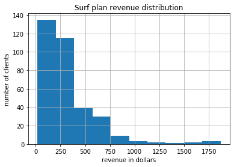

```python
# plot a histogram for surf plan revenue
user_usage_data.query('plan == "surf"')['year_revenue'].hist()
plt.title('Surf plan revenue distribution')
plt.xlabel('revenue in dollars')
plt.ylabel('number of clients')
plt.show()
```

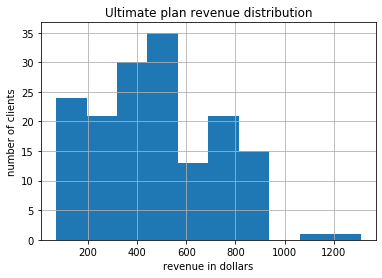

```python
# graph ultimate plan revenue
user_usage_data.query('plan == "ultimate"')['year_revenue'].hist()
plt.title('Ultimate plan revenue distribution')
plt.xlabel('revenue in dollars')
plt.ylabel('number of clients')
plt.show()
plt.show()
```

*Conclusion*

- the revenue brought in by surf plan clients is right skewed where as the revenue from ulitimat plan clients are more even dispersed

```python
# make a df with only the total columns
use_totals_plan = use_totals[['user_id', 'plan', 'total_calls', 'mins_total', 'texts_total', 'gbs_total']]
print('Use totals per client')
use_totals_plan.head()
```

```
Use totals per client
```

|  | user_id | plan | total_calls | mins_total | texts_total | gbs_total |
| --- | --- | --- | --- | --- | --- | --- |
| 0 | 1000 | ultimate | 16.0 | 117.0 | 11.0 | 2.0 |
| 1 | 1001 | surf | 261.0 | 1641.0 | 207.0 | 79.0 |
| 2 | 1002 | surf | 113.0 | 778.0 | 88.0 | 40.0 |
| 3 | 1003 | surf | 149.0 | 1041.0 | 50.0 | 27.0 |
| 4 | 1004 | surf | 370.0 | 2619.0 | 177.0 | 153.0 |

```python
# create a table of plan usage totals
plan_use_totals = use_totals_plan.pivot_table(index='plan', values=('total_calls', 'mins_total', 'texts_total', 'gbs_total'), aggfunc='sum')
print('total usage in 2018')
plan_use_totals.head()
```

```
total usage in 2018
```

| plan | gbs_total | mins_total | texts_total | total_calls |
| --- | --- | --- | --- | --- |
| surf | 25604.0 | 636856.0 | 49014.0 | 94084.0 |
| ultimate | 12184.0 | 292537.0 | 27037.0 | 43651.0 |

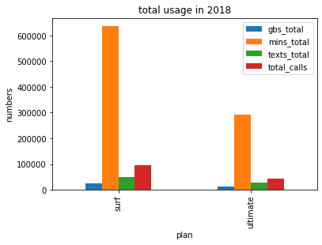

```python
plan_use_totals.plot(kind='bar')
plt.title('total usage in 2018')
plt.ylabel('numbers')
plt.show()
```

**Student's Comment V.2.**

- I made graphs with both distributions in one graph

**Reviewer's comment. V.3.** It is very good that we can compare 2 plans on the one graph! Well done!

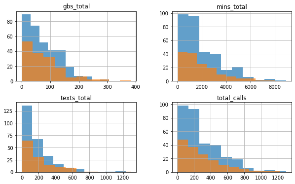

```python
# graph the distributions
surf_dist = use_totals_plan.query('plan == "surf"').hist(figsize=(10, 6), alpha=0.7)
ultimate_dist = use_totals_plan.query('plan == "ultimate"').hist(figsize=(10, 6), ax=surf_dist, alpha=0.7)
```

```
Surf plan usage distributions
```

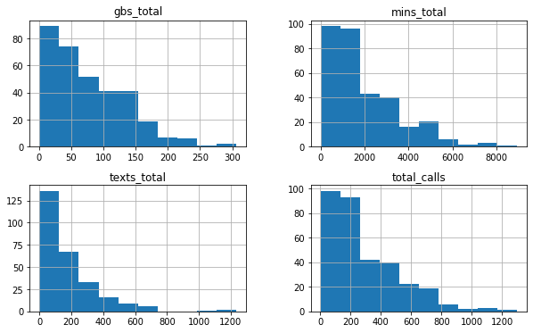

```python
# graph surf plan usage distributions
use_totals_plan.query('plan == "surf"').hist(figsize=(10, 6))
print('Surf plan usage distributions')
plt.show()
```

```
Ultimate plan usage distributions
```

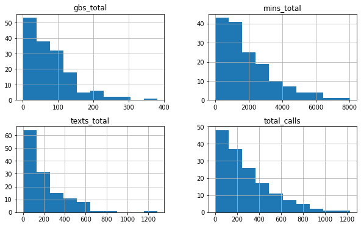

```python
# graph ultimate plan usage distributions
use_totals_plan.query('plan == "ultimate"').hist(figsize=(10, 6))
print('Ultimate plan usage distributions')
plt.show()
```

*Conclusion*

- The number of calls, minutes, texts, and gbs used follow the same trend between plans, however the surf plan has more total

**Reviewer's comment. V.2.** Graphs with total values is more understandable. Excellent! Also, we can compare both plans on the one graph. :)

*Minutes tables and graphs*

```python
# Create a table of the total minutes used per month per plan
user_usage_mins_sum = user_usage_data.pivot_table(index='plan',
                                               values=['mins_1', 'mins_2', 'mins_3', 'mins_4', 'mins_5', 'mins_6',
                                                       'mins_7', 'mins_8', 'mins_9', 'mins_10', 'mins_11', 'mins_12'],
                                               aggfunc='sum')
print('Total minutes used per month per plan')
user_usage_mins_sum.head()
```

```
Total minutes used per month per plan
```

| plan | mins_1 | mins_10 | mins_11 | mins_12 | mins_2 | mins_3 | mins_4 | mins_5 | mins_6 | mins_7 | mins_8 | mins_9 |
| --- | --- | --- | --- | --- | --- | --- | --- | --- | --- | --- | --- | --- |
| surf | 386.0 | 96270.0 | 113219.0 | 142459.0 | 2532.0 | 7163.0 | 16646.0 | 29070.0 | 39546.0 | 51425.0 | 62801.0 | 75942.0 |
| ultimate | 735.0 | 45124.0 | 53460.0 | 65466.0 | 2663.0 | 3434.0 | 6659.0 | 11142.0 | 16467.0 | 23852.0 | 28243.0 | 35585.0 |

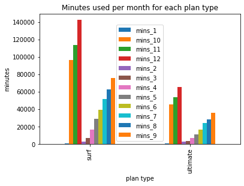

```python
# graph the results
user_usage_mins_sum.plot(kind='bar')
plt.title('Minutes used per month for each plan type')
plt.xlabel('plan type')
plt.ylabel('minutes')
plt.show()
```

```python
# Create a table of the average minutes used per month per plan
user_usage_mins_mean = user_usage_data.pivot_table(index='plan',
                                               values=['mins_1', 'mins_2', 'mins_3', 'mins_4', 'mins_5', 'mins_6',
                                                       'mins_7', 'mins_8', 'mins_9', 'mins_10', 'mins_11', 'mins_12', ],
                                               aggfunc='mean')
print('Average minutes used per month per plan')
user_usage_mins_mean.head()
```

```
Average minutes used per month per plan
```

| plan | mins_1 | mins_10 | mins_11 | mins_12 | mins_2 | mins_3 | mins_4 | mins_5 | mins_6 | mins_7 | mins_8 | mins_9 |
| --- | --- | --- | --- | --- | --- | --- | --- | --- | --- | --- | --- | --- |
| surf | 1.184049 | 295.306748 | 347.297546 | 436.990798 | 7.766871 | 21.972393 | 51.06135 | 89.171779 | 121.306748 | 157.745399 | 192.641104 | 232.950920 |
| ultimate | 4.741935 | 291.122581 | 344.903226 | 422.361290 | 17.180645 | 22.154839 | 42.96129 | 71.883871 | 106.238710 | 153.883871 | 182.212903 | 229.580645 |

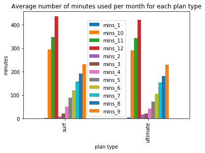

```python
# graph the results
user_usage_mins_mean.plot(kind='bar')
plt.title('Average number of minutes used per month for each plan type')
plt.xlabel('plan type')
plt.ylabel('minutes')
plt.show()
```

```python
# Create a table of the standard deviation of minutes used per month per plan
user_usage_mins_std = user_usage_data.pivot_table(index='plan',
                                               values=['mins_1', 'mins_2', 'mins_3', 'mins_4', 'mins_5', 'mins_6',
                                                       'mins_7', 'mins_8', 'mins_9', 'mins_10', 'mins_11', 'mins_12', ],
                                               aggfunc='std')
print('Standard deviation of minutes used per month per plan')
user_usage_mins_std.head()
```

```
Standard deviation of minutes used per month per plan
```

| plan | mins_1 | mins_10 | mins_11 | mins_12 | mins_2 | mins_3 | mins_4 | mins_5 | mins_6 | mins_7 | mins_8 | mins_9 |
| --- | --- | --- | --- | --- | --- | --- | --- | --- | --- | --- | --- | --- |
| surf | 16.532761 | 258.435169 | 241.661302 | 245.801302 | 57.347799 | 92.392886 | 145.990524 | 195.587638 | 216.536864 | 249.759847 | 248.528674 | 248.465154 |
| ultimate | 33.871959 | 269.112281 | 266.091352 | 243.094709 | 94.626091 | 98.797191 | 126.065582 | 172.461739 | 193.499961 | 251.407130 | 247.393319 | 265.936592 |

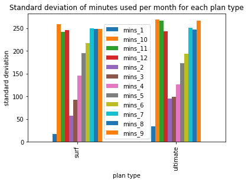

```python
# graph the results
user_usage_mins_std.plot(kind='bar')
plt.title('Standard deviation of minutes used per month for each plan type')
plt.xlabel('plan type')
plt.ylabel('standard deviation')
plt.show()
```

```python
# Create a table of the dispersion of minutes used per month per plan
user_usage_mins_var = user_usage_data.pivot_table(index='plan',
                                               values=['mins_1', 'mins_2', 'mins_3', 'mins_4', 'mins_5', 'mins_6',
                                                       'mins_7', 'mins_8', 'mins_9', 'mins_10', 'mins_11', 'mins_12', ],
                                               aggfunc=np.var)
print('Dispersion of minutes used per month per plan')
user_usage_mins_var.head()
```

```
Dispersion of minutes used per month per plan
```

| plan | mins_1 | mins_10 | mins_11 | mins_12 | mins_2 | mins_3 | mins_4 | mins_5 | mins_6 | mins_7 | mins_8 | mins_9 |
| --- | --- | --- | --- | --- | --- | --- | --- | --- | --- | --- | --- | --- |
| surf | 273.332176 | 66788.736385 | 58400.185040 | 60418.279915 | 3288.770099 | 8536.445389 | 21313.233148 | 38254.524247 | 46888.213308 | 62379.981133 | 61766.501567 | 61734.932968 |
| ultimate | 1147.309594 | 72421.419941 | 70804.607457 | 59095.037453 | 8954.097026 | 9760.884960 | 15892.530959 | 29743.051362 | 37442.234855 | 63205.544868 | 61203.454378 | 70722.271052 |

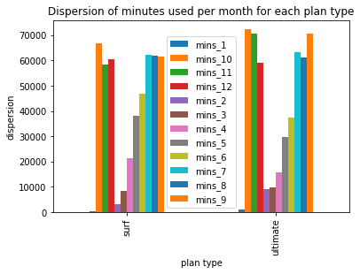

```python
# graph the results
user_usage_mins_var.plot(kind='bar')
plt.title('Dispersion of minutes used per month for each plan type')
plt.xlabel('plan type')
plt.ylabel('dispersion')
plt.show()
```

*Texts tables and graphs*

```python
# Create a table of the total messages sent per month per plan
user_usage_texts_sum = user_usage_data.pivot_table(index='plan',
                                               values=['texts_1', 'texts_2', 'texts_3', 'texts_4', 'texts_5', 'texts_6',
                                                       'texts_7', 'texts_8', 'texts_9', 'texts_10', 'texts_11', 'texts_12', ],
                                               aggfunc='sum')
print('Total messages sent per month per plan')
user_usage_texts_sum.head()
```

```
Total messages sent per month per plan
```

| plan | texts_1 | texts_10 | texts_11 | texts_12 | texts_2 | texts_3 | texts_4 | texts_5 | texts_6 | texts_7 | texts_8 | texts_9 |
| --- | --- | --- | --- | --- | --- | --- | --- | --- | --- | --- | --- | --- |
| surf | 21.0 | 8020.0 | 9165.0 | 12275.0 | 108.0 | 351.0 | 870.0 | 1849.0 | 2454.0 | 3271.0 | 4662.0 | 5968.0 |
| ultimate | 62.0 | 4181.0 | 4903.0 | 6796.0 | 151.0 | 243.0 | 463.0 | 931.0 | 1379.0 | 1937.0 | 2732.0 | 3259.0 |

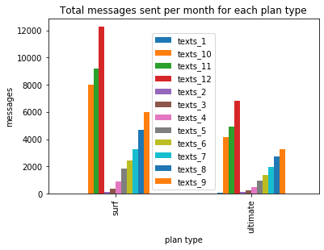

```python
# graph the results
user_usage_texts_sum.plot(kind='bar')
plt.title('Total messages sent per month for each plan type')
plt.xlabel('plan type')
plt.ylabel('messages')
plt.show()
```

```python
# Create a table of the average messages sent per month per plan
user_usage_texts_mean = user_usage_data.pivot_table(index='plan',
                                               values=['texts_1', 'texts_2', 'texts_3', 'texts_4', 'texts_5', 'texts_6',
                                                       'texts_7', 'texts_8', 'texts_9', 'texts_10', 'texts_11', 'texts_12', ],
                                               aggfunc='mean')
print('Average messages sent per month per plan')
user_usage_texts_mean.head()
```

```
Average messages sent per month per plan
```

| plan | texts_1 | texts_10 | texts_11 | texts_12 | texts_2 | texts_3 | texts_4 | texts_5 | texts_6 | texts_7 | texts_8 | texts_9 |
| --- | --- | --- | --- | --- | --- | --- | --- | --- | --- | --- | --- | --- |
| surf | 0.077778 | 29.703704 | 33.944444 | 45.462963 | 0.400000 | 1.300000 | 3.222222 | 6.848148 | 9.088889 | 12.114815 | 17.266667 | 22.103704 |
| ultimate | 0.469697 | 31.674242 | 37.143939 | 51.484848 | 1.143939 | 1.840909 | 3.507576 | 7.053030 | 10.446970 | 14.674242 | 20.696970 | 24.689394 |

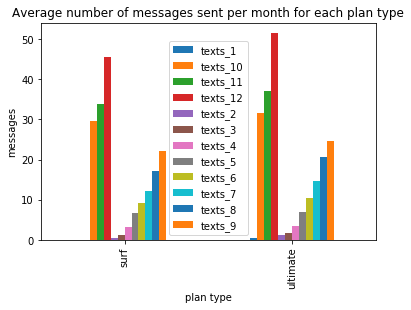

```python
# graph the results
user_usage_texts_mean.plot(kind='bar')
plt.title('Average number of messages sent per month for each plan type')
plt.xlabel('plan type')
plt.ylabel('messages')
plt.show()
```

```python
# Create a table of the standard deviation of messages sent per month per plan
user_usage_texts_std = user_usage_data.pivot_table(index='plan',
                                               values=['texts_1', 'texts_2', 'texts_3', 'texts_4', 'texts_5', 'texts_6',
                                                       'texts_7', 'texts_8', 'texts_9', 'texts_10', 'texts_11', 'texts_12', ],
                                               aggfunc='std')
print('Standard deviation of messages sent per month per plan')
user_usage_texts_std.head()
```

```
Standard deviation of messages sent per month per plan
```

| plan | texts_1 | texts_10 | texts_11 | texts_12 | texts_2 | texts_3 | texts_4 | texts_5 | texts_6 | texts_7 | texts_8 | texts_9 |
| --- | --- | --- | --- | --- | --- | --- | --- | --- | --- | --- | --- | --- |
| surf | 1.278019 | 35.246361 | 32.614463 | 37.486113 | 4.017064 | 6.823505 | 11.714171 | 18.903470 | 21.780578 | 24.363072 | 28.560039 | 30.204821 |
| ultimate | 3.781109 | 35.024418 | 35.218648 | 37.921873 | 6.741840 | 9.439101 | 12.190283 | 21.338177 | 22.361470 | 26.338517 | 31.782404 | 31.787254 |

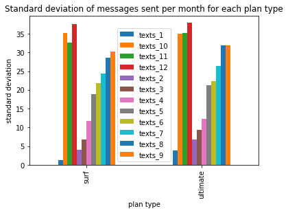

```python
# graph the results
user_usage_texts_std.plot(kind='bar')
plt.title('Standard deviation of messages sent per month for each plan type')
plt.xlabel('plan type')
plt.ylabel('standard deviation')
plt.show()
```

```python
# Create a table of the dispersion of messages sent per month per plan
user_usage_texts_var = user_usage_data.pivot_table(index='plan',
                                               values=['texts_1', 'texts_2', 'texts_3', 'texts_4', 'texts_5', 'texts_6',
                                                       'texts_7', 'texts_8', 'texts_9', 'texts_10', 'texts_11', 'texts_12', ],
                                               aggfunc=np.var)
print('Dispersion of messages sent per month per plan')
user_usage_texts_var.head()
```

```
Dispersion of messages sent per month per plan
```

| plan | texts_1 | texts_10 | texts_11 | texts_12 | texts_2 | texts_3 | texts_4 | texts_5 | texts_6 | texts_7 | texts_8 | texts_9 |
| --- | --- | --- | --- | --- | --- | --- | --- | --- | --- | --- | --- | --- |
| surf | 1.633333 | 1242.305934 | 1063.703222 | 1405.208660 | 16.136803 | 46.560223 | 137.221809 | 357.341168 | 474.393556 | 593.559259 | 815.675836 | 912.331213 |
| ultimate | 14.296785 | 1226.709866 | 1240.353169 | 1438.068471 | 45.452406 | 89.096634 | 148.602996 | 455.317777 | 500.035334 | 693.717499 | 1010.121212 | 1010.429505 |

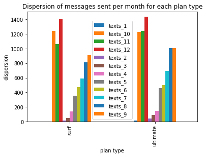

```python
# graph the results
user_usage_texts_var.plot(kind='bar')
plt.title('Dispersion of messages sent per month for each plan type')
plt.xlabel('plan type')
plt.ylabel('dispersion')
plt.show()
```

*gb tables and graphs*

```python
# Create a table of the total data used per month per plan
user_usage_gbs_sum = user_usage_data.pivot_table(index='plan',
                                               values=['gbs_1', 'gbs_2', 'gbs_3', 'gbs_4', 'gbs_5', 'gbs_6',
                                                       'gbs_7', 'gbs_8', 'gbs_9', 'gbs_10', 'gbs_11', 'gbs_12'],
                                               aggfunc='sum')
print('Total gbs used per month per plan')
user_usage_gbs_sum.head()
```

```
Total gbs used per month per plan
```

| plan | gbs_1 | gbs_10 | gbs_11 | gbs_12 | gbs_2 | gbs_3 | gbs_4 | gbs_5 | gbs_6 | gbs_7 | gbs_8 | gbs_9 |
| --- | --- | --- | --- | --- | --- | --- | --- | --- | --- | --- | --- | --- |
| surf | 10.0 | 4126.0 | 4650.0 | 5800.0 | 110.0 | 312.0 | 611.0 | 1087.0 | 1502.0 | 2042.0 | 2735.0 | 3238.0 |
| ultimate | 29.0 | 1878.0 | 2174.0 | 2778.0 | 121.0 | 221.0 | 343.0 | 489.0 | 725.0 | 973.0 | 1267.0 | 1463.0 |

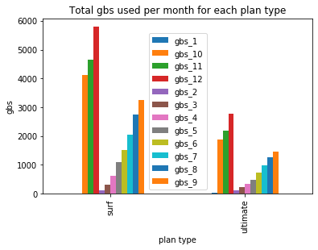

```python
# graph the results
user_usage_gbs_sum.plot(kind='bar')
plt.title('Total gbs used per month for each plan type')
plt.xlabel('plan type')
plt.ylabel('gbs')
plt.show()
```

```python
# Create a table of the average data used per month per plan
user_usage_gbs_mean = user_usage_data.pivot_table(index='plan',
                                               values=['gbs_1', 'gbs_2', 'gbs_3', 'gbs_4', 'gbs_5', 'gbs_6',
                                                       'gbs_7', 'gbs_8', 'gbs_9', 'gbs_10', 'gbs_11', 'gbs_12'],
                                               aggfunc='mean')
print('Average gbs used per month per plan')
user_usage_gbs_mean.head()
```

```
Average gbs used per month per plan
```

| plan | gbs_1 | gbs_10 | gbs_11 | gbs_12 | gbs_2 | gbs_3 | gbs_4 | gbs_5 | gbs_6 | gbs_7 | gbs_8 | gbs_9 |
| --- | --- | --- | --- | --- | --- | --- | --- | --- | --- | --- | --- | --- |
| surf | 0.030120 | 12.427711 | 14.006024 | 17.469880 | 0.331325 | 0.939759 | 1.840361 | 3.274096 | 4.524096 | 6.150602 | 8.237952 | 9.753012 |
| ultimate | 0.184713 | 11.961783 | 13.847134 | 17.694268 | 0.770701 | 1.407643 | 2.184713 | 3.114650 | 4.617834 | 6.197452 | 8.070064 | 9.318471 |

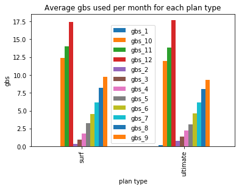

```python
# graph the results
user_usage_gbs_mean.plot(kind='bar')
plt.title('Average gbs used per month for each plan type')
plt.xlabel('plan type')
plt.ylabel('gbs')
plt.show()
```

```python
# Create a table of the standard deviation of data used per month per plan
user_usage_gbs_std = user_usage_data.pivot_table(index='plan',
                                               values=['gbs_1', 'gbs_2', 'gbs_3', 'gbs_4', 'gbs_5', 'gbs_6',
                                                       'gbs_7', 'gbs_8', 'gbs_9', 'gbs_10', 'gbs_11', 'gbs_12'],
                                               aggfunc='std')
print('Standard deviation of gbs used per month per plan')
user_usage_gbs_std.head()
```

```
Standard deviation of gbs used per month per plan
```

| plan | gbs_1 | gbs_10 | gbs_11 | gbs_12 | gbs_2 | gbs_3 | gbs_4 | gbs_5 | gbs_6 | gbs_7 | gbs_8 | gbs_9 |
| --- | --- | --- | --- | --- | --- | --- | --- | --- | --- | --- | --- | --- |
| surf | 0.452248 | 10.266136 | 8.977311 | 8.930869 | 2.225609 | 4.019137 | 5.242327 | 6.997638 | 7.974053 | 9.405030 | 10.303873 | 9.827477 |
| ultimate | 1.265021 | 10.297426 | 9.461234 | 8.312535 | 3.777247 | 5.819899 | 6.489461 | 7.267744 | 8.398363 | 9.385914 | 10.268270 | 9.894338 |

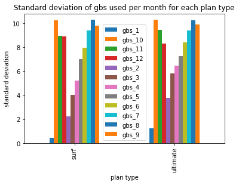

```python
# graph the results
user_usage_gbs_std.plot(kind='bar')
plt.title('Standard deviation of gbs used per month for each plan type')
plt.xlabel('plan type')
plt.ylabel('standard deviation')
plt.show()
```

```python
# Create a table of the dispersion of data used per month per plan
user_usage_gbs_var = user_usage_data.pivot_table(index='plan',
                                               values=['gbs_1', 'gbs_2', 'gbs_3', 'gbs_4', 'gbs_5', 'gbs_6',
                                                       'gbs_7', 'gbs_8', 'gbs_9', 'gbs_10', 'gbs_11', 'gbs_12'],
                                               aggfunc=np.var)
print('dispersion of gbs used per month per plan')
user_usage_gbs_var.head()
```

```
dispersion of gbs used per month per plan
```

| plan | gbs_1 | gbs_10 | gbs_11 | gbs_12 | gbs_2 | gbs_3 | gbs_4 | gbs_5 | gbs_6 | gbs_7 | gbs_8 | gbs_9 |
| --- | --- | --- | --- | --- | --- | --- | --- | --- | --- | --- | --- | --- |
| surf | 0.204528 | 105.393550 | 80.592109 | 79.760419 | 4.953336 | 16.153460 | 27.481991 | 48.966940 | 63.58552 | 88.454592 | 106.169794 | 96.579296 |
| ultimate | 1.600278 | 106.036992 | 89.514944 | 69.098236 | 14.267598 | 33.871223 | 42.113098 | 52.820105 | 70.53250 | 88.095378 | 105.437367 | 97.897926 |

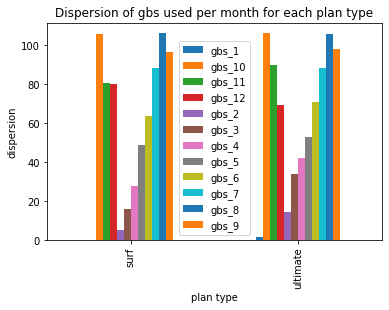

```python
# graph the results
user_usage_gbs_var.plot(kind='bar')
plt.title('Dispersion of gbs used per month for each plan type')
plt.xlabel('plan type')
plt.ylabel('dispersion')
plt.show()
```

# 4 Analyse The Data Conclusion

*Actions performed*

- The following for the users of each plan required per month were examined
  - minutes
  - texts
  - volume of data
- The following calculations were performed:
  - mean
  - dispersion
  - standard deviation
- Bar graphs were plotted
- The results are described below

*General trends*

- The surf plan in general had more minutes used, texts sent, and gbs used
  - However the average, standard deviation, and dispersion of these are about the same for each plan
- There is an increase of use as the months pass, i.e. January has the least use (mins, texts, gbs) and December has the most with increase use from January to December
  - This is likely due to acquiring new clients as the year goes on but could also be because there may be more to discuss/do in the later months of the year (for example, holidays and school related things)

**Reviewer's comment. V.2.** Thank you for your conclusions! Thay are very deteiled. It help to understand project deeply. :)

# 5 Test the hypothesis questions

*Info on testing hypothesis*

A test of a statistical hypothesis always begins with a statement of the hypothesis. First, we state the **null hypothesis**, **H₀**. For example, "The mean of the population in question equals *A*," where *A* is some number. The **alternative hypothesis**, **H₁**, is based on H₀. For this H₀, H₁ would be, "The mean of the population does not equal *A*." H₀ is always stated with an equal sign.

We construct a distribution based on the assumption that H₀ is true. In this case, it would be a normal distribution around the parameter of interest, the mean. The variance or its square root, the standard deviation (a measure of the distribution's dispersion, or scatter), is estimated based on the sample.

Hypothesis on the Equality of the Means of Two Populations

Sometimes you need to compare the means of two different statistical populations. In order to test your hypothesis that the means of two statistical populations are equal based on samples taken from them, apply the method `scipy.stats.ttest_ind()`. The method takes the following parameters:

- `array1`, `array2` are arrays containing the samples.
- `equal_var` is an optional parameter that specifies whether or not the variances of the populations should be considered equal.

*Plan of Action*

- Formulate the null and alternative hypotheses
- Obtain needed information to perform tests
  - tables
  - queries
- Evaluate dispersion of data sets
  - if the dispersion is similar then the parameter `equal_var=True`
  - if the dispersion is not similar then the parameter `equal_var=False`
- Perform tests

*Test the following hypotheses*

- Null hypothesis: The average revenue from users of Ultimate and Surf calling plans differs.
- Althernative hypothesis: The average revenue from users of Ultimate and Surf calling plans do not differ.
- Null hypothesis: The average revenue from users in NY-NJ area is different from that of the users from other regions.
- Alternative hypothesis: The average revenue from users in NY-NJ area is not different form that of the users from other regions.

**Updated Hypotheses V.2.**

Test 1:

Null: The average revenue from users of Ulitmate and Surf calling plans is the same.  
Alt: The average revenue from users of Ultimate and Surf calling plans differs.

Test 2:

Null: The average revenue from users in NY-NJ area is the same from that of the users from other regions. Alt: The average revenue from users in NY-NJ area is different from that of the users from other regions.

*Acquire data necessary for testing the hypothesis:*

- Null hypothesis: The average revenue from users of Ultimate and Surf calling plans differs.
- Althernative hypothesis: The average revenue from users of Ultimate and Surf calling plans do not differ.

**Reviewer's comment** Very good formularation of hypotheses!

**Reviewer's comment** Please, use total values here too. :)

**Student's Comment**

- I do not know how you want me to use the new totals here (calls, mins, texts, gb or revenue).
- I will need a population for each plan, so I used the monthly revenue totals (the questions were focused on the monthly totals throughout the project)

**Reviewer's comment. V.2.** Please, use here your new table with total values. :)

**Student's Comment V.2.**

- Once again, the revenue based on the totals minutes, texts, and gbs (vs monthly totals) dont properly account for the total yearly revenue, it needs to account for the monthly revenue generated on each month
- While I was thinking about this, I did realize I answered the hypotheses wrong because of the way I set up the null hypotheses - I have updated the tests and conclusions

**Reviewer's comment. V.3.** So, last variant is very good! Also, we can use column. It help to avoid to create a list. :)

```python
# create a table with the total charges for each month per plan
user_usage_sum_table = user_usage_data.pivot_table(index='plan',
                                               values=['jan_total', 'feb_total', 'mar_total', 'apr_total', 'may_total', 'jun_total',
                                                       'jul_total', 'aug_total', 'sep_total','oct_total', 'nov_total', 'dec_total'],
                                               aggfunc='sum')
print('Total charges per month per plan')
user_usage_sum_table.head()
```

```
Total charges per month per plan
```

| plan | apr_total | aug_total | dec_total | feb_total | jan_total | jul_total | jun_total | mar_total | may_total | nov_total | oct_total | sep_total |
| --- | --- | --- | --- | --- | --- | --- | --- | --- | --- | --- | --- | --- |
| surf | 3502.93 | 11759.43 | 21693.88 | 1328.34 | 600 | 9209.41 | 6426.71 | 2393.23 | 5077.49 | 16520.3 | 16213.15 | 12462.75 |
| ultimate | 3703.00 | 8253.00 | 11347.00 | 2170.00 | 1330 | 7042.00 | 6167.00 | 2926.00 | 4571.00 | 10577.0 | 9625.00 | 8925.00 |

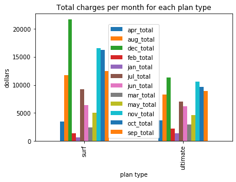

```python
# graph the results
user_usage_sum_table.plot(kind='bar')
plt.title('Total charges per month for each plan type')
plt.xlabel('plan type')
plt.ylabel('dollars')
plt.show()
```

```python
# create a table with the dispersion of total charges for each month per plan
user_usage_var_table = user_usage_data.pivot_table(index='plan',
                                               values=['jan_total', 'feb_total', 'mar_total', 'apr_total', 'may_total', 'jun_total',
                                                       'jul_total', 'aug_total', 'sep_total','oct_total', 'nov_total', 'dec_total'],
                                               aggfunc=np.var)
print('Dispersion of total charges per month per plan')
user_usage_var_table.head()
```

```
Dispersion of total charges per month per plan
```

| plan | apr_total | aug_total | dec_total | feb_total | jan_total | jul_total | jun_total | mar_total | may_total | nov_total | oct_total | sep_total |
| --- | --- | --- | --- | --- | --- | --- | --- | --- | --- | --- | --- | --- |
| surf | 396.147522 | 2518.624925 | 4451.927735 | 86.385144 | 32.361104 | 1782.583649 | 987.939190 | 270.130762 | 807.071670 | 2414.540477 | 2896.344875 | 1930.391598 |
| ultimate | 1131.550000 | 1126.756522 | 393.301087 | 766.576087 | 513.206522 | 1244.006522 | 1277.713043 | 983.907065 | 1200.652174 | 456.350543 | 836.671196 | 931.597283 |

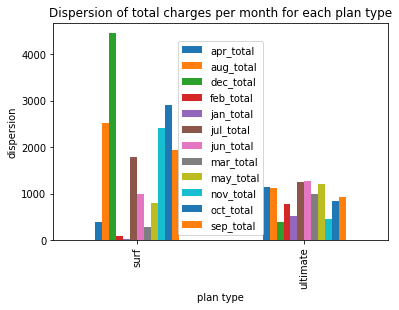

```python
# graph the results
user_usage_var_table.plot(kind='bar')
plt.title('Dispersion of total charges per month for each plan type')
plt.xlabel('plan type')
plt.ylabel('dispersion')
plt.show()
```

```python
# perform a query to get the totals for the surf plan
surf_query = user_usage_sum_table.query('plan == "surf"')
print('Total charges per month for Surf plan')
surf_query.head()
```

```
Total charges per month for Surf plan
```

| plan | apr_total | aug_total | dec_total | feb_total | jan_total | jul_total | jun_total | mar_total | may_total | nov_total | oct_total | sep_total |
| --- | --- | --- | --- | --- | --- | --- | --- | --- | --- | --- | --- | --- |
| surf | 3502.93 | 11759.43 | 21693.88 | 1328.34 | 600 | 9209.41 | 6426.71 | 2393.23 | 5077.49 | 16520.3 | 16213.15 | 12462.75 |

```python
# create a list of the results
surf_monthly_totals = list(surf_query.values)
print('List of total charges per month for Surf plan')
print(surf_monthly_totals)
```

```
List of total charges per month for Surf plan
[array([ 3502.93, 11759.43, 21693.88,  1328.34,   600.  ,  9209.41,
        6426.71,  2393.23,  5077.49, 16520.3 , 16213.15, 12462.75])]
```

```python
# perform a query to get the totals for the surf plan
ultimate_query = user_usage_sum_table.query('plan == "ultimate"')
print('Total charges per month for Ultimate plan')
ultimate_query.head()
```

```
Total charges per month for Ultimate plan
```

| plan | apr_total | aug_total | dec_total | feb_total | jan_total | jul_total | jun_total | mar_total | may_total | nov_total | oct_total | sep_total |
| --- | --- | --- | --- | --- | --- | --- | --- | --- | --- | --- | --- | --- |
| ultimate | 3703.0 | 8253.0 | 11347.0 | 2170.0 | 1330 | 7042.0 | 6167.0 | 2926.0 | 4571.0 | 10577.0 | 9625.0 | 8925.0 |

```python
# create a list of the results
ultimate_monthly_totals = list(ultimate_query.values)
print('List of total charges per month for Ultimate plan')
print(ultimate_monthly_totals)
```

```
List of total charges per month for Ultimate plan
[array([ 3703.,  8253., 11347.,  2170.,  1330.,  7042.,  6167.,  2926.,
        4571., 10577.,  9625.,  8925.])]
```

*Test hypothesis:*

- Null hypothesis: The average revenue from users of Ultimate and Surf calling plans differs.
- Althernative hypothesis: The average revenue from users of Ultimate and Surf calling plans do not differ.

```python
# Test a hypothesis about the means of two statistical populations based on samples taken from them

surf_monthly_totals_list = [3502.93, 11759.43, 21693.88, 1328.34, 600, 9209.41, 6426.71, 2393.23, 5077.49, 16520.3, 16213.15, 12462.75]
ultimate_monthly_totals_list = [3703., 8253., 11347., 2170., 1330., 7042., 6167., 2926., 4571., 10577.,  9625.,  8925.]

alpha = 0.05 # 5% as the critical statistical significance level

results = st.ttest_ind(
    surf_monthly_totals_list,
    ultimate_monthly_totals_list,
        equal_var = False)

print('p-value: ', results.pvalue)

if results.pvalue < alpha: # your code: compare the p-value you get with the significance level):
    print("We reject the null hypothesis that the average revenue from users of Ultimate and Surf calling plans differs.")
    print("The alternative hypthosesis is true: The average revenue from users of Ultimate and Surf calling plans do not differ.")
else:
    print("We can't reject the null hypothesis that the average revenue from users of Ultimate and Surf calling plans differs.")
    print("The null hypothesis is true: The average revenue from users of Ultimate and Surf calling plans differs.")
```

```
p-value:  0.265610638650257
We can't reject the null hypothesis that the average revenue from users of Ultimate and Surf calling plans differs.
The null hypothesis is true: The average revenue from users of Ultimate and Surf calling plans differs.
```

**Updated Hypotheses V.2.**

Test 1:

Null: The average revenue from users of Ulitmate and Surf calling plans is the same.  
Alt: The average revenue from users of Ultimate and Surf calling plans differs.

```python
# Test a hypothesis about the means of two statistical populations based on samples taken from them

surf_monthly_totals_list = [3502.93, 11759.43, 21693.88, 1328.34, 600, 9209.41, 6426.71, 2393.23, 5077.49, 16520.3, 16213.15, 12462.75]
ultimate_monthly_totals_list = [3703., 8253., 11347., 2170., 1330., 7042., 6167., 2926., 4571., 10577.,  9625.,  8925.]

alpha = 0.05 # 5% as the critical statistical significance level

results = st.ttest_ind(
    surf_monthly_totals_list,
    ultimate_monthly_totals_list,
        equal_var = False)

print('p-value: ', results.pvalue)

if results.pvalue < alpha: # your code: compare the p-value you get with the significance level):
    print("We reject the null hypothesis that the average revenue from users of Ulitmate and Surf calling plans is the same.")
    print("The alternative hypthosesis is true: The average revenue from users of Ultimate and Surf calling plans differs.")
else:
    print("We can't reject the null hypothesis that the average revenue from users of Ulitmate and Surf calling plans is the same.")
    print("The null hypothesis is true: The average revenue from users of Ulitmate and Surf calling plans is the same.")
```

```
p-value:  0.265610638650257
We can't reject the null hypothesis that the average revenue from users of Ulitmate and Surf calling plans is the same.
The null hypothesis is true: The average revenue from users of Ulitmate and Surf calling plans is the same.
```

```python
# determine the average yearly revenue for each plan
avg_surf_revenue = sum(surf_monthly_totals_list) / len(surf_monthly_totals_list)
print('Average Surf revenue:', avg_surf_revenue)
avg_ultimate_revenue = sum(ultimate_monthly_totals_list) / len(ultimate_monthly_totals_list)
print('Average Ultimate revenue:', avg_ultimate_revenue)
```

```
Average Surf revenue: 8932.301666666666
Average Ultimate revenue: 6386.333333333333
```

*Acquire data necessary to test the hypothesis:*

- Null hypothesis: The average revenue from users in NY-NJ area is different from that of the users from other regions.
- Alternative hypothesis: The average revenue from users in NY-NJ area is not different form that of the users from other regions.

```python
# create a table with the monthly totals for cities
user_usage_city_table = user_usage_data.pivot_table(index='city',
                                               values=['jan_total', 'feb_total', 'mar_total', 'apr_total', 'may_total', 'jun_total',
                                                       'jul_total', 'aug_total', 'sep_total','oct_total', 'nov_total', 'dec_total'],
                                               aggfunc='sum')
print('Client citys with monthly totals')
user_usage_city_table.head()
```

```
Client citys with monthly totals
```

| city | apr_total | aug_total | dec_total | feb_total | jan_total | jul_total | jun_total | mar_total | may_total | nov_total | oct_total | sep_total |
| --- | --- | --- | --- | --- | --- | --- | --- | --- | --- | --- | --- | --- |
| Albany-Schenectady-Troy, NY MSA | 0.00 | 50.03 | 161.44 | 0.0 | 0 | 0.00 | 0.00 | 0.0 | 0.00 | 181.17 | 184.38 | 161.95 |
| Albuquerque, NM MSA | 20.00 | 70.00 | 80.00 | 0.0 | 0 | 100.24 | 92.01 | 20.0 | 110.00 | 163.18 | 150.00 | 160.00 |
| Atlanta-Sandy Springs-Roswell, GA MSA | 220.00 | 520.00 | 980.34 | 70.0 | 70 | 360.00 | 290.00 | 200.0 | 220.00 | 866.74 | 725.04 | 574.23 |
| Austin-Round Rock-Georgetown, TX MSA | 21.05 | 130.00 | 324.89 | 20.0 | 0 | 60.93 | 132.76 | 20.0 | 82.76 | 223.90 | 300.71 | 93.96 |
| Bakersfield, CA MSA | 20.00 | 130.00 | 160.00 | 20.0 | 20 | 110.00 | 90.00 | 20.0 | 20.00 | 160.00 | 170.00 | 210.00 |

```python
# perform a query to find monthly average totals for NY-NJ
ny_nj_query = user_usage_city_table.query('city == "New York-Newark-Jersey City, NY-NJ-PA MSA"').sum()
print('NY-NJ monthly totals')
ny_nj_query
```

```
NY-NJ monthly totals
```

```
apr_total    1113.03
aug_total    3038.39
dec_total    4846.67
feb_total     560.00
jan_total     280.00
jul_total    2444.11
jun_total    1953.44
mar_total     765.64
may_total    1447.13
nov_total    4486.28
oct_total    4090.75
sep_total    3394.10
dtype: float64
```

```python
# create a list of the results
ny_nj_monthly_totals = list(ny_nj_query)
print('list of NY-NJ monthly totals')
ny_nj_monthly_totals
```

```
list of NY-NJ monthly totals
```

```
[1113.03,
 3038.39,
 4846.669999999999,
 560.0,
 280.0,
 2444.11,
 1953.4399999999998,
 765.64,
 1447.13,
 4486.280000000001,
 4090.7499999999995,
 3394.1000000000004]
```

```python
# perform a query to find monthly average totals for all other cities
not_ny_nj_query = user_usage_city_table.query('city != "New York-Newark-Jersey City, NY-NJ-PA MSA"').sum()
print('City monthly totals excluding NY-NJ')
not_ny_nj_query
```

```
City monthly totals excluding NY-NJ
```

```
apr_total     6092.90
aug_total    16974.04
dec_total    28194.21
feb_total     2938.34
jan_total     1650.00
jul_total    13807.30
jun_total    10640.27
mar_total     4553.59
may_total     8201.36
nov_total    22611.02
oct_total    21747.40
sep_total    17993.65
dtype: float64
```

```python
# create a list of the results
not_ny_nj_monthly_totals = list(not_ny_nj_query)
print('list of city monthly totals excluding NY-NJ')
not_ny_nj_monthly_totals
```

```
list of city monthly totals excluding NY-NJ
```

```
[6092.900000000001,
 16974.039999999997,
 28194.210000000003,
 2938.34,
 1650.0,
 13807.3,
 10640.27,
 4553.59,
 8201.36,
 22611.020000000004,
 21747.399999999998,
 17993.650000000005]
```

```python
# examine the dispersion of the groups
print('Dispersion:')
print('NY-NJ:', np.var(ny_nj_monthly_totals))
print('All cities, excluding NY-NJ:', np.var(not_ny_nj_monthly_totals))
```

```
Dispersion:
NY-NJ: 2324821.2633916666
All cities, excluding NY-NJ: 68234087.47063336
```

*Test null hypothesis:*

- Null hypothesis: The average revenue from users in NY-NJ area is different from that of the users from other regions.
- Alternative hypothesis: The average revenue from users in NY-NJ area is not different form that of the users from other regions.

```python
# Test a hypothesis about the means of two statistical populations based on samples taken from them

alpha = 0.05 # 5% as the critical statistical significance level

results = st.ttest_ind(
    ny_nj_monthly_totals,
    not_ny_nj_monthly_totals,
        equal_var = False)

print('p-value: ', results.pvalue)

if results.pvalue < alpha: # your code: compare the p-value you get with the significance level):
    print("We reject the null hypothesis that the average revenue from users in NY-NJ area is different from that of the users from other regions.")
    print("The alternative hypothesis is true: The average revenue from users in NY-NJ area is not different form that of the users from other regions.")
else:
    print("We can't reject the null hypothesis that the average revenue from users in NY-NJ area is different from that of the users from other regions.")
    print("The null hypothesis is true: The average revenue from users in NY-NJ area is different from that of the users from other regions.")
```

```
p-value:  0.0013392798899379058
We reject the null hypothesis that the average revenue from users in NY-NJ area is different from that of the users from other regions.
The alternative hypothesis is true: The average revenue from users in NY-NJ area is not different form that of the users from other regions.
```

**Updated Hypotheses V.2.**

Test 2:

Null: The average revenue from users in NY-NJ area is the same from that of the users from other regions.

Alt: The average revenue from users in NY-NJ area is different from that of the users from other regions.

```python
# Test a hypothesis about the means of two statistical populations based on samples taken from them

alpha = 0.05 # 5% as the critical statistical significance level

results = st.ttest_ind(
    ny_nj_monthly_totals,
    not_ny_nj_monthly_totals,
        equal_var = False)

print('p-value: ', results.pvalue)

if results.pvalue < alpha: # your code: compare the p-value you get with the significance level):
    print("We reject the null hypothesis that the average revenue from users in NY-NJ area is the same from that of the users from other regions.")
    print("The alternative hypothesis is true: The average revenue from users in NY-NJ area is different from that of the users from other regions.")
else:
    print("We can't reject the null hypothesis that the average revenue from users in NY-NJ area is the same from that of the users from other regions.")
    print("The null hypothesis is true: The average revenue from users in NY-NJ area is the same from that of the users from other regions.")
```

```
p-value:  0.0013392798899379058
We reject the null hypothesis that the average revenue from users in NY-NJ area is the same from that of the users from other regions.
The alternative hypothesis is true: The average revenue from users in NY-NJ area is different from that of the users from other regions.
```

```python
# determine the average yearly revenue for each data set
avg_ny_nj_revenue = sum(ny_nj_monthly_totals) / len(ny_nj_monthly_totals)
print('Average NY-NJ revenue:', avg_ny_nj_revenue)
avg_other_city_revenue = sum(not_ny_nj_monthly_totals) / len(not_ny_nj_monthly_totals)
print('Average revenue from cities excluding NY-NJ:', avg_other_city_revenue)
```

```
Average NY-NJ revenue: 2368.295
Average revenue from cities excluding NY-NJ: 12950.340000000002
```

# 5 Conclusion of Testing hypotheses

*Actions Performed*

- Hypotheses were created
  - Null hypothesis was formulated based on the question asked/provided
  - Alternative hypothesis is the opposite of the null hypothesis
- Tables were created to obtain the data of interest
- Queries were performed to obtain specific information for futher analysis
- The dispersion was evaluated to determine similarity or lack of similarity
  - in both cases it was determined to not be similar, therefore the parameter `equal_var=False`
- The equality of the means of the two populations were tested in both tests
  - Both tests were comparing the means of two different statistical poplulations
    - the `scipy.stats.ttest_ind()` method was used
  - 5% was used as the critical statistical significance level, this is a standard level to use in these types of tests

*Results*

*Null hypothesis: The average revenue from users of Ultimate and Surf calling plans differs.*

*Althernative hypothesis: The average revenue from users of Ultimate and Surf calling plans do not differ.*

*Null hypothesis: The average revenue from users in NY-NJ area is different from that of the users from other regions.*

*Alternative hypothesis: The average revenue from users in NY-NJ area is not different form that of the users from other regions.*

**Updated Results V.2.**

Test 1: *Null hypothesis is true: The average revenue from users of Ulitmate and Surf calling plans is the same.*

- Average Surf revenue: 8932.301666666666
- Average Ultimate revenue: 6386.333333333333
- While these averages are not exact, they may not be statistically different according to this test

Test 2: *The alternative hypothesis is true: The average revenue from users in NY-NJ area is different from that of the users from other regions.*

- Average NY-NJ revenue: 2368.295
- Average revenue from cities excluding NY-NJ: 12950.340000000002
- These averages are statistically different

# 6 Overall Conclusion

*Task: Megaline's commercial department wants to know which plan brings in more revenue, Surf or Ultimate, so they can adjust their advertising budget.*

*Actions performed*

- Dataframes were created and the general information was studied
- The data was cleaned up
  - columns were renamed to be more informative
  - the impact of missing values was examined
  - no duplicates were found
  - data types were changed to more appropriate types
  - calls and internet sessions with 0 values were examined
- Requested information was calculated and processed
  - The number of calls made each month
  - The number of minutes used each month - rounded up
  - The number of texts sent each month
  - The volume of data used each month - rounded up
  - monthly minutes charge
  - monthly texts charge
  - monthly data charge
  - total monthly charge
- The data was analyzed
  - For each month per plan the following was examined:
    - minutes
    - texts
    - volume of data
    - mean
    - dispersion
    - standard deviation
  - graphs were made and evaluated
- Hypotheses were tested
  - Null hypothesis: The average revenue from users of Ultimate and Surf calling plans differs.
  - Null hypothesis: The average revenue from users in NY-NJ area is different from that of the users from other regions.

*Conclusions and Recomendations*

To answer the commercial departments question:

**Updated Results V.2.**

- Based on the tests, the average revenues do not differ statistically, but when you look at the hard numbers they do
  - The surf plan brings in more revenue overall based on this data set

**Reviewer's comment. V.2.** Excellent conclusion. As I said, you conclusions are very detailed and it is perfect. Clients like to read about project, because they (mostly) do not know code. So, it is very good! :)

#### Reviewer's part

```python
#total calls and count calls per user
calls_monthly = (calls.groupby(['user_id', 'call_month']).agg({'call_id': 'count', 'duration_min':'sum'})).reset_index()
calls_monthly.columns = ['user_id', 'month','calls_count', 'duration_sum']
calls_monthly['duration_sum'] = np.ceil(calls_monthly['duration_sum']).astype('int')

display(calls_monthly.head())
```

|  | user_id | month | calls_count | duration_sum |
| --- | --- | --- | --- | --- |
| 0 | 1000 | 12 | 16 | 117 |
| 1 | 1001 | 8 | 27 | 172 |
| 2 | 1001 | 9 | 49 | 298 |
| 3 | 1001 | 10 | 65 | 375 |
| 4 | 1001 | 11 | 64 | 405 |

```python
#total gb per user
gb_monthly = (internet.groupby(['user_id', 'session_month']).agg({'mb_used': 'sum'})).reset_index()
gb_monthly.columns = ['user_id', 'month','mb_sum']
gb_monthly['mb_sum'] = gb_monthly['mb_sum'] / 1024
gb_monthly.rename(columns={'mb_sum': 'gb_used'}, inplace=True)
gb_monthly['gb_used'] = np.ceil(gb_monthly['gb_used']).astype('int')

display(gb_monthly.head())
```

|  | user_id | month | gb_used |
| --- | --- | --- | --- |
| 0 | 1000 | 12 | 2 |
| 1 | 1001 | 8 | 7 |
| 2 | 1001 | 9 | 14 |
| 3 | 1001 | 10 | 22 |
| 4 | 1001 | 11 | 19 |

```python
#total message per user
message_monthly = messages.groupby(['user_id', 'message_month']).agg({'message_date': 'count'}).reset_index()
message_monthly.columns = ['user_id', 'month','message_count']

display(message_monthly.head())
```

|  | user_id | month | message_count |
| --- | --- | --- | --- |
| 0 | 1000 | 12 | 11 |
| 1 | 1001 | 8 | 30 |
| 2 | 1001 | 9 | 44 |
| 3 | 1001 | 10 | 53 |
| 4 | 1001 | 11 | 36 |

```python
#rename for future merge
users.rename(columns = {'plan':'plan_name'}, inplace = True)

#merge with users
users_calls = pd.merge(users, calls_monthly, on='user_id', how='outer')

#we do not need this columns
del users_calls['age']
del users_calls['first_name']
del users_calls['last_name']
del users_calls['reg_date']
del users_calls['churn_date']

#merge tables
users_calls_message = pd.merge(users_calls, message_monthly, on=('user_id', 'month'), how='outer')
users_calls_message_internet = pd.merge(users_calls_message, gb_monthly, on=('user_id', 'month'), how='outer')
month_user_receipt = pd.merge(users_calls_message_internet, plans, on='plan_name')

display(month_user_receipt.head())
```

|  | user_id | city | plan_name | month | calls_count | duration_sum | message_count | gb_used | messages_included | mb_per_month_included | minutes_included | usd_monthly_pay | usd_per_gb | usd_per_message | usd_per_minute | gb_per_month_included |
| --- | --- | --- | --- | --- | --- | --- | --- | --- | --- | --- | --- | --- | --- | --- | --- | --- |
| 0 | 1000 | Atlanta-Sandy Springs-Roswell, GA MSA | ultimate | 12.0 | 16.0 | 117.0 | 11.0 | 2.0 | 1000 | 30720 | 3000 | 70 | 7 | 0.01 | 0.01 | 30.0 |
| 1 | 1006 | San Francisco-Oakland-Berkeley, CA MSA | ultimate | 11.0 | 2.0 | 10.0 | 15.0 | 3.0 | 1000 | 30720 | 3000 | 70 | 7 | 0.01 | 0.01 | 30.0 |
| 2 | 1006 | San Francisco-Oakland-Berkeley, CA MSA | ultimate | 12.0 | 9.0 | 55.0 | 139.0 | 32.0 | 1000 | 30720 | 3000 | 70 | 7 | 0.01 | 0.01 | 30.0 |
| 3 | 1008 | Orlando-Kissimmee-Sanford, FL MSA | ultimate | 10.0 | 71.0 | 451.0 | 21.0 | 17.0 | 1000 | 30720 | 3000 | 70 | 7 | 0.01 | 0.01 | 30.0 |
| 4 | 1008 | Orlando-Kissimmee-Sanford, FL MSA | ultimate | 11.0 | 63.0 | 423.0 | 37.0 | 24.0 | 1000 | 30720 | 3000 | 70 | 7 | 0.01 | 0.01 | 30.0 |

```python
#0 is best here
month_user_receipt = month_user_receipt.fillna(0)
month_user_receipt.info()
```

```
<class 'pandas.core.frame.DataFrame'>
Int64Index: 2277 entries, 0 to 2276
Data columns (total 16 columns):
user_id                  2277 non-null int64
city                     2277 non-null object
plan_name                2277 non-null object
month                    2277 non-null float64
calls_count              2277 non-null float64
duration_sum             2277 non-null float64
message_count            2277 non-null float64
gb_used                  2277 non-null float64
messages_included        2277 non-null int64
mb_per_month_included    2277 non-null int64
minutes_included         2277 non-null int64
usd_monthly_pay          2277 non-null int64
usd_per_gb               2277 non-null int64
usd_per_message          2277 non-null float64
usd_per_minute           2277 non-null float64
gb_per_month_included    2277 non-null float64
dtypes: float64(8), int64(6), object(2)
memory usage: 302.4+ KB
```

```python
#number of users
len(month_user_receipt.user_id.unique())
```

```
500
```